# RQ1: What baseline factors predict participation in TEDS?

Analyses run in docker container bignardig/tidyverse451:v7

Updated on 8-Jan-2026 to replace household variable with derived single parent variable.

# Load Data

```r
source("0_load_data.R")
set.seed(1)

df_rq1 = df %>%
  filter(twin == 1) %>%
  filter(acontact == 1) %>%
  select(all_of(c("cohort",rq1x, rq1y_twin1, rq1y_twin2)))

df_rq1x = df_rq1 %>%
  select(all_of(rq1x))

options(width = 900)
```

At some time points, participants in cohorts 3 & 4 were not all eligible to take part

## List of variables

```r
data.frame(
  var = c(rq1x, rq1y_twin),
  labels = c(rq1x_labels, rq1y_twin_labels),
  clean_labels = c(rq1x_labels_clean, rq1y_twin_labels)
)
```

| var | labels | clean_labels |
| --- | --- | --- |
| sex1 | Twin sex, 0female 1male | Twin Sex |
| amumagetw | Age in years of natural mother at time of birth of twins | Mother age at birth |
| adadagetw | Age in years of natural father at time of birth of twins | Father age at birth |
| asingle | Single Parent | Single Parent |
| zygos | Twin pair zygosity (best available estimate), 1MZ 2DZ | Zygosity |
| amedtot | Mother medical risk factor composite scale (1st Contact), standardised | Mother medical risk |
| afasoc2 | Father SOC employment level (1st Contact), 1-9 | Father employment level |
| afahqual | Male parent highest qualification level (1st Contact), see value labels | Father education level |
| amosoc2 | Mother SOC employment level (1st Contact), 1-9 | Mother employment level |
| amohqual | Female parent highest qualification level (1st Contact), see value labels | Mother education level |

[output cut: 20 more lines]

## Singly Impute Missing Predictor/Baseline Data

### Imputation

```r
daddy_issues = df_rq1 %>%
  select(adadagetw, afasoc2, afahqual)

df_rq1_imputed = df_rq1 %>%
  # select(-adadagetw, -afasoc2, -afahqual) %>% # removing these eliminates imputation warnings
  mice(method = "pmm", m = 1, maxit = 75, seed = 1)
df_rq1_imputed$loggedEvents
```

|  | it | im | dep | meth | out |
| --- | --- | --- | --- | --- | --- |
| 1 | 1 | 1 | hasgeno1 | pmm | aethniccAsian, aethniccBlack, aethniccMixed race, aethniccOther |
| 2 | 1 | 1 | hasgeno2 | pmm | aethniccAsian, aethniccBlack, aethniccMixed race, aethniccOther |
| 3 | 2 | 1 | hasgeno1 | pmm | aethniccAsian, aethniccBlack, aethniccMixed race, aethniccOther |
| 4 | 2 | 1 | hasgeno2 | pmm | aethniccAsian, aethniccBlack, aethniccMixed race, aethniccOther |
| 5 | 3 | 1 | hasgeno1 | pmm | aethniccAsian, aethniccBlack, aethniccMixed race, aethniccOther |
| 6 | 3 | 1 | hasgeno2 | pmm | aethniccAsian, aethniccBlack, aethniccMixed race, aethniccOther |
| 7 | 4 | 1 | hasgeno1 | pmm | aethniccAsian, aethniccBlack, aethniccMixed race, aethniccOther |
| 8 | 4 | 1 | hasgeno2 | pmm | aethniccAsian, aethniccBlack, aethniccMixed race, aethniccOther |
| 9 | 5 | 1 | hasgeno1 | pmm | aethniccAsian, aethniccBlack, aethniccMixed race, aethniccOther |
| 10 | 5 | 1 | hasgeno2 | pmm | aethniccAsian, aethniccBlack, aethniccMixed race, aethniccOther |

[output cut: 140 more lines]

```r
df_rq1_imputed = complete(df_rq1_imputed)

vars_to_na = c("btwdata","ctwdata", "gcdata","icdata","jcdata","pcwebdata")

df_rq1_imputed = df_rq1_imputed %>%
  mutate(
      across(starts_with(vars_to_na), ~ ifelse(cohort %in% c("Cohort 3: twins born Sep-95 to Aug-96","Cohort 4: twins born Sep-96 to Dec-96"), NA, .))
    )

# df_rq1_imputed$gcdata1 %>% table(., useNA = "always")
```

### Full list of imputation variables (RQ1)

The table below lists every variable included in the single imputation of baseline/predictor data used for RQ1 (see Singly Impute Missing Predictor/Baseline Data), showing the study wave, description, TEDS variable code, observed range or factor levels, number of non-missing observations, and percent missing prior to imputation.

```r
# Function to map variable prefix to study wave
get_study_wave = function(var_name) {
  prefix = substr(var_name, 1, 1)
  wave_map = c(
    "a" = "1st Contact",
    "b" = "2 Year",
    "c" = "3 Year",
    "d" = "4 Year",
    "e" = "In Home",
    "g" = "7 Year",
    "h" = "8 Year",
    "i" = "9 Year",
    "j" = "10 Year",
    "l" = "12 Year",
    "n" = "14 Year",
    "p" = "16 Year",
    "r" = "18 Year",
    "u" = "21 Year",
    "z" = "26 Year"
  )
  if (var_name %in% c("sex1", "zygos")) return("")
  return(wave_map[prefix])
}

rq1_imputation_vars = colnames(df_rq1)
impute_vars_labels = var_to_label(rq1_imputation_vars) %>%
  sapply(., function(x) ifelse(is.null(x[1]), "", x[1]))

# Create formatted table for imputation variables
v_impute = data.frame(
  `Study.Wave` = sapply(rq1_imputation_vars, get_study_wave),
  Description = impute_vars_labels,
  `Teds Code` = ifelse(rq1_imputation_vars %in% colnames(df0), rq1_imputation_vars, paste0(rq1_imputation_vars, "*")),
  `Range or Level` = sapply(rq1_imputation_vars, function(var) {
    if (var %in% colnames(df)) {
      if (class(df[[var]]) == "numeric") {
        paste0(round(min(df[[var]], na.rm = TRUE), 2), " - ", round(max(df[[var]], na.rm = TRUE), 2))
      } else if (is.factor(df[[var]])) {
        factor_levels = levels(df[[var]])
        paste(c(paste0(factor_levels[1], "*"), factor_levels[-1]), collapse = ", ")
      } else {
        paste(unique(df[[var]]), collapse = ", ")
      }
    } else {
      "Variable not found"
    }
  }),
  N = sapply(rq1_imputation_vars, function(var) {
    if (var %in% colnames(df)) {
      sum(!is.na(df[[var]]))
    } else {
      0
    }
  })
) %>%
  mutate(
    `Percent Missing` = (nrow(df)-N)/nrow(df)
  )

v_impute$Study.Wave[v_impute$Teds.Code=="cohort"]=""

gt(v_impute) %>%
  fmt_percent(`Percent Missing`) %>%
  cols_label_with(fn = ~ gsub("\\.", " ", .x)) %>%
  tab_style(
    style = cell_text(size = px(12)),
    locations = cells_body()
  ) %>%
  tab_style(
    style = cell_text(size = px(12)),
    locations = cells_column_labels()
  ) %>%
  # cols_hide(N) %>%
  tab_source_note(
    source_note = "Note. Range or Level shows min-max values for numeric variables or factor levels for categorical variables (reference level marked with asterisk). Teds codes marked with an asterisk have been derived or modified from the original dataset. N indicate the number of non-missing observations."
  ) %>%
  tab_options(
    table.width = "70%"
  ) %>%
  cols_width(
    Description ~ px(300),
    everything() ~ px(120)
  )
```

| Study Wave | Description | Teds Code | Range or Level | N | Percent Missing |
| --- | --- | --- | --- | --- | --- |
|  | School cohort, see value labels | cohort | Cohort 1: twins born Jan-94 to Aug-94*, Cohort 2: twins born Sep-94 to Aug-95, Cohort 3: twins born Sep-95 to Aug-96, Cohort 4: twins born Sep-96 to Dec-96 | 26040 | 0.00% |
|  | Twin sex, 0female 1male | sex1 | 0 - 1 | 26040 | 0.00% |
| 1st Contact | Age in years of natural mother at time of birth of twins | amumagetw | 14 - 45 | 25563 | 1.83% |
| 1st Contact | Age in years of natural father at time of birth of twins | adadagetw | 16 - 66 | 22975 | 11.77% |
| 1st Contact | Single Parent | asingle | cohabiting biological mother and father / cohabiting biological parent with other*, single parent | 25587 | 1.74% |
|  | Twin pair zygosity (best available estimate), 1MZ 2DZ | zygos | 1*, 2 | 26040 | 0.00% |
| 1st Contact | Mother medical risk factor composite scale (1st Contact), standardised | amedtot | -2.49 - 4.98 | 25864 | 0.68% |
| 1st Contact | Father SOC employment level (1st Contact), 1-9 | afasoc2* | 1*, 2, 3, 4, 5, 6, 7, 8, 9, caring for children at home, no job | 23111 | 11.25% |
| 1st Contact | Male parent highest qualification level (1st Contact), see value labels | afahqual | CSE grade 1 or O-level/GCSE grade A-C*, no qualifications, CSE grade 2-5 or O-level/GCSE grade D-G, A-level or S-level, HNC, HND, undergraduate degree, postgraduate qualification | 23049 | 11.49% |
| 1st Contact | Mother SOC employment level (1st Contact), 1-9 | amosoc2* | caring for children at home*, 1, 2, 3, 4, 5, 6, 7, 8, 9, no job | 25650 | 1.50% |
| 1st Contact | Female parent highest qualification level (1st Contact), see value labels | amohqual | no qualifications*, CSE grade 2-5 or O-level/GCSE grade D-G, CSE grade 1 or O-level/GCSE grade A-C, A-level or S-level, HNC, HND, undergraduate degree, postgraduate qualification | 25629 | 1.58% |
| 1st Contact | Twin medical risk factor composite scale (1st Contact), standardised | atwmed1 | -1.88 - 3.33 | 25832 | 0.80% |
| 1st Contact | Ethnic origin of twins, original codes (1st Contact), see value labels | aethnicc | White*, Asian, Black, Mixed race, Other | 25946 | 0.36% |
| 1st Contact | Main language spoken at home (1st Contact), see value labels | alang | other*, English, English + other | 25678 | 1.39% |
| 1st Contact | Number of older siblings (1st Contact), see value labels | anoldsib | 0*, 1, 2, 3, 4, 5 or more | 26040 | 0.00% |
| 1st Contact | Number of younger siblings (1st Contact), see value labels | anyngsib | 0*, 1, 2 or more | 26040 | 0.00% |
| 1st Contact | Member of a Twins Club (1st Contact), 1Y 0N | atwclub | 0*, 1 | 25148 | 3.43% |
| 1st Contact | Twins looked after by anyone else (1st Contact), 1Y 0N | alookels | 0*, 1 | 24791 | 4.80% |
| 1st Contact | Smoked cigarettes while pregnant (1st Contact), 1Y 0N | asmoke | 0*, 1 | 25932 | 0.41% |
| 1st Contact | Drank alcohol while pregnant (1st Contact), 1Y 0N | adrink | 0*, 1 | 25783 | 0.99% |
| 1st Contact | Severe stress during pregnancy (1st Contact), 1Y 0N | astress | 0*, 1 | 25889 | 0.58% |
| 16 Year | Principal Component of 1998 pollution variables | pollution1998pca | -2.47 - 4.57 | 23030 | 11.56% |
| 4 Year | Twin booklet data present (4 Year), 1Y 0N | dtwdata1 | 0 - 1 | 26040 | 0.00% |
| 12 Year | Twin web data (at least one test) present at 12, 1Y 0N | lcwdata1 | 0 - 1 | 26040 | 0.00% |
| 12 Year | Child questionnaire data present at 12, 1Y 0N | lcqdata1 | 0 - 1 | 26040 | 0.00% |
| 16 Year | Child behaviour booklet data present at 16, 1Y 0N | pcbhdata1 | 0 - 1 | 26040 | 0.00% |
| 18 Year | Twin questionnaire data present at 18, 1Y 0N | rcqdata1 | 0 - 1 | 26040 | 0.00% |
| 21 Year | TEDS21 phase 1 twin qnr data present, 1Y 0N | u1cdata1 | 0 - 1 | 26040 | 0.00% |
| 26 Year | TEDS26 twin MHQ data present, 1Y 0N | zmhdata1 | 0 - 1 | 26040 | 0.00% |
| 26 Year | CATSLife twin web study: data are present, 1Y 0N | zcdata1 | 0 - 1 | 26040 | 0.00% |
| 8 Year | Genotyped | hasgeno1 | 1, 0, NA | 23933 | 8.09% |
| 4 Year | Twin booklet data present (4 Year), 1Y 0N | dtwdata2 | 0 - 1 | 26040 | 0.00% |
| 12 Year | Twin web data (at least one test) present at 12, 1Y 0N | lcwdata2 | 0 - 1 | 26040 | 0.00% |
| 12 Year | Child questionnaire data present at 12, 1Y 0N | lcqdata2 | 0 - 1 | 26040 | 0.00% |
| 16 Year | Child behaviour booklet data present at 16, 1Y 0N | pcbhdata2 | 0 - 1 | 26040 | 0.00% |
| 18 Year | Twin questionnaire data present at 18, 1Y 0N | rcqdata2 | 0 - 1 | 26040 | 0.00% |
| 21 Year | TEDS21 phase 1 twin qnr data present, 1Y 0N | u1cdata2 | 0 - 1 | 26040 | 0.00% |
| 26 Year | TEDS26 twin MHQ data present, 1Y 0N | zmhdata2 | 0 - 1 | 26040 | 0.00% |
| 26 Year | CATSLife twin web study: data are present, 1Y 0N | zcdata2 | 0 - 1 | 26040 | 0.00% |
| 8 Year | Genotyped | hasgeno2 | 1, 0, NA | 23933 | 8.09% |

Note. Range or Level shows min-max values for numeric variables or factor levels for categorical variables (reference level marked with asterisk). Teds codes marked with an asterisk have been derived or modified from the original dataset. N indicate the number of non-missing observations.

### Create Long Imputed dataset for twin-level analyses

For imputation, because predictor variables are only measured at the family level, imputation is performed in the wide format with one row per family.

For modelling twin-level outcomes with glm(), we need to convert outcomes to a long format with one row per twin.

```r
df_rq1_imputed$famid = 1:nrow(df_rq1_imputed)

df1 = df_rq1_imputed[c("famid", rq1x, rq1y_twin1)]
df2 = df_rq1_imputed[c("famid", rq1x, rq1y_twin2)]

  # Rename twin2 columns to match twin1 column names
colnames(df2) = colnames(df1)

df_rq1_long = rbind(df1, df2) %>%
  arrange(famid)

rm(df1, df2)

# Set outcome to missing for participants ineligible at specific time points

df_rq1_long$btwdata1 %>% table(., useNA = "always")
```

```
.
<NA>
   0
```

```r
df_rq1_long %>% sapply(., function(x) length(which(is.na(x))))
```

[output not shown]

## Correlation of participation over time

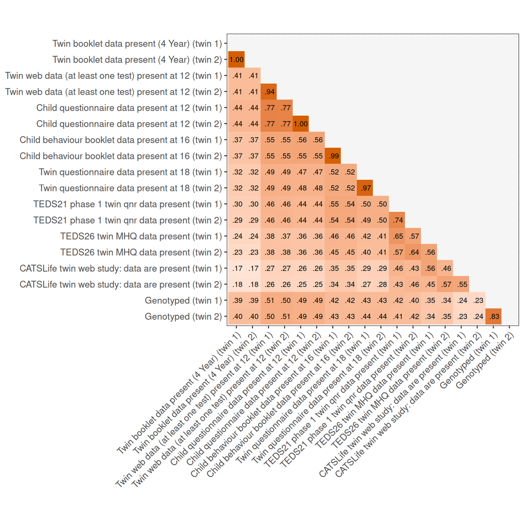

```r
df %>%
  filter(twin == 1) %>%
  select(starts_with(rq1y_twin)) %>%
  select(matches("1$|2$")) %>%
  rename_with(.fn = function(x) var_to_label(x, twinsuffix = TRUE)) %>%
  rename_with(.fn = function(x) gsub(", 1Y 0N","",x)) %>%
  gbtoolbox::plot_correlations(
    sample_size = FALSE,
    confidence_interval = FALSE
  )
```

```r
save_plot("1_correlation_participation", width = 9, height = 9)


# df %>%
#   select(randomfamid,twin,all_of(rq1y)) %>%
#   filter(twin == 1) %>%
#   select(-twin, -randomfamid) %>%
#   `colnames<-`(c(rq1y_labels)) %>%
#   gbtoolbox::plot_correlations(
#     sample_size = FALSE,
#     confidence_interval = FALSE
#   ) +
#   labs(
#     title = "Correlation between participation at different \ntime points",
#     subtitle = "N = 13020 (Number of families)"
#     )
#
# save_plot("1_correlation_participation", width = 9, height = 9)
```

View full-size plot

## List of predictor variables

```r
cbind(rq1x, rq1x_labels) %>%
  knitr::kable()
```

| rq1x | rq1x_labels |
| --- | --- |
| sex1 | Twin sex, 0female 1male |
| amumagetw | Age in years of natural mother at time of birth of twins |
| adadagetw | Age in years of natural father at time of birth of twins |
| asingle | Single Parent |
| zygos | Twin pair zygosity (best available estimate), 1MZ 2DZ |
| amedtot | Mother medical risk factor composite scale (1st Contact), standardised |
| afasoc2 | Father SOC employment level (1st Contact), 1-9 |
| afahqual | Male parent highest qualification level (1st Contact), see value labels |
| amosoc2 | Mother SOC employment level (1st Contact), 1-9 |
| amohqual | Female parent highest qualification level (1st Contact), see value labels |
| atwmed1 | Twin medical risk factor composite scale (1st Contact), standardised |
| aethnicc | Ethnic origin of twins, original codes (1st Contact), see value labels |
| alang | Main language spoken at home (1st Contact), see value labels |
| anoldsib | Number of older siblings (1st Contact), see value labels |
| anyngsib | Number of younger siblings (1st Contact), see value labels |
| atwclub | Member of a Twins Club (1st Contact), 1Y 0N |
| alookels | Twins looked after by anyone else (1st Contact), 1Y 0N |
| asmoke | Smoked cigarettes while pregnant (1st Contact), 1Y 0N |
| adrink | Drank alcohol while pregnant (1st Contact), 1Y 0N |
| astress | Severe stress during pregnancy (1st Contact), 1Y 0N |
| pollution1998pca | Principal Component of 1998 pollution variables |

## List of outcome variables

```r
cbind(rq1y_twin1, rq1y_twin_labels) %>%
  knitr::kable()
```

| rq1y_twin1 | rq1y_twin_labels |
| --- | --- |
| dtwdata1 | Twin booklet data present (4 Year), 1Y 0N |
| lcwdata1 | Twin web data (at least one test) present at 12, 1Y 0N |
| lcqdata1 | Child questionnaire data present at 12, 1Y 0N |
| pcbhdata1 | Child behaviour booklet data present at 16, 1Y 0N |
| rcqdata1 | Twin questionnaire data present at 18, 1Y 0N |
| u1cdata1 | TEDS21 phase 1 twin qnr data present, 1Y 0N |
| zmhdata1 | TEDS26 twin MHQ data present, 1Y 0N |
| zcdata1 | CATSLife twin web study: data are present, 1Y 0N |
| hasgeno1 | Genotyped |

# Twin-Level Logistic Regressions to each participation outcome

## Fit Models

Fit logistic regression models to each participation outcome

```r
set.seed(1)

twinmodels = list()

for (i in seq_along(rq1y_twin)){

  cat(i, "/", length(rq1y_twin),"\n")
  rq1x_i = if (rq1y_twin[i] == "hasgeno") rq1x[rq1x != "aethnicc"] else rq1x
  formula <- as.formula(paste(rq1y_twin1[i], "~", paste(rq1x_i, collapse = "+")))
  twinmodels[[i]] = glm(formula, data = df_rq1_long, family = binomial, na.action = na.omit)

}
```

```
1 / 9
2 / 9
3 / 9
4 / 9
5 / 9
6 / 9
7 / 9
8 / 9
9 / 9
```

## Calc participant participation predictions

This approach doesn’t give us standard errors for our predictions.

** Predictions for participants at cohorts 3-4 at specific timepoints are kept in here!! **

** For plotting purposes, the intercept is removed from predictions. **

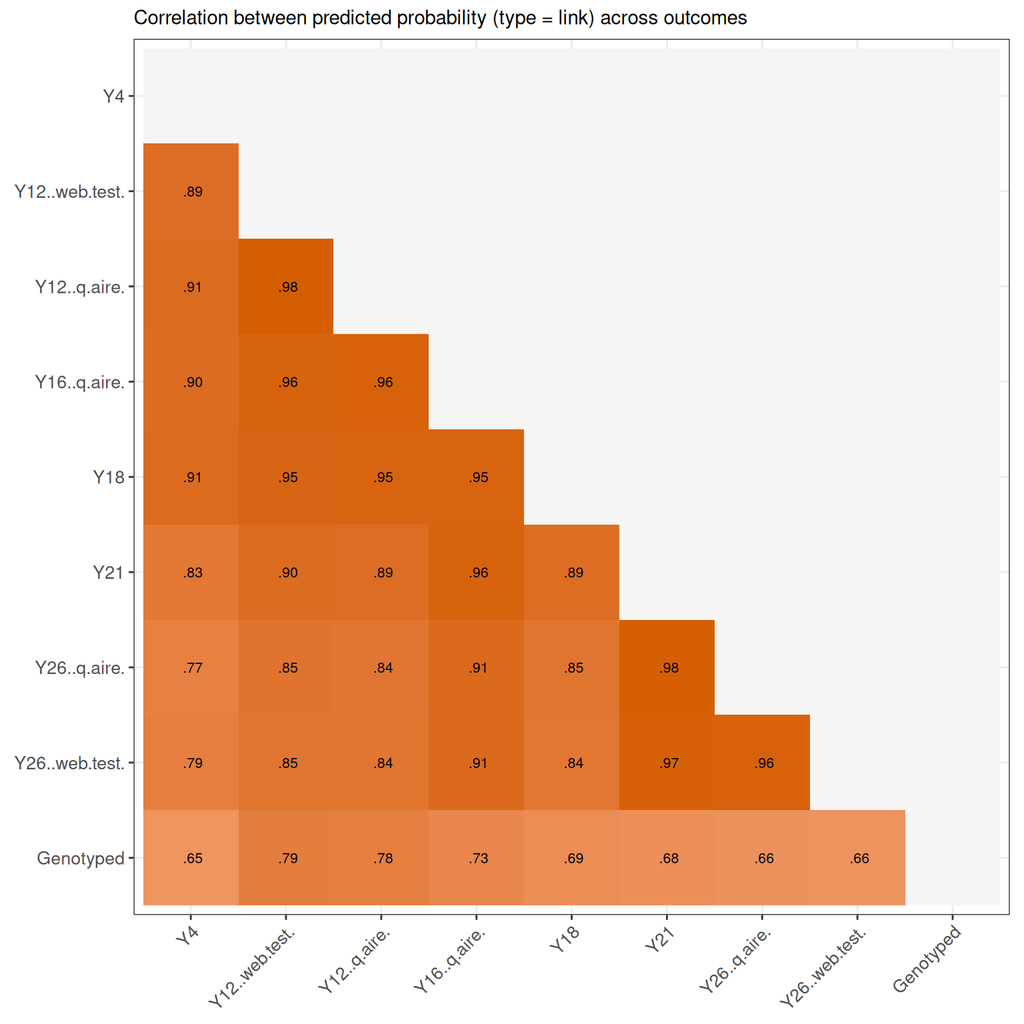

```r
set.seed(1)

twinmodels_predictions = list()

for (i in seq_along(rq1y_twin)){
  twinmodels_predictions[[i]] = twinmodels[[i]]$data

  twinmodels_predictions[[i]]$prediction = twinmodels[[i]] %>%
    predict(
      .,
      newdata = df_rq1_long,
      type = "link",
      na.action = na.pass,
    ) - twinmodels[[i]]$coefficients[1] # removed intercept term

}
names(twinmodels_predictions) = rq1y_twin

twinmodels_predictions = bind_rows(twinmodels_predictions, .id = "outcome")

twinmodels_predictions %>%
  select(famid, outcome, prediction) %>%
  mutate(
    outcome = rq1y_twin_labels_clean_extrashort[match(.$outcome, rq1y_twin)]
  ) %>%
  group_by(outcome) %>%
  filter(!duplicated(famid)) %>%
  pivot_wider(
    values_from = "prediction",
    names_from  = "outcome",
    id_cols     = "famid"
  ) %>%
  data.frame() %>%
  select(-famid) %>%
  gbtoolbox::plot_correlations(
    sample_size = FALSE
  ) +
  labs(
    subtitle = "Correlation between predicted probability (type = link) across outcomes"
  )
```

```r
save_plot("1_rq1_predicted_probability_plots", width = 8, height = 8)
```

View full-size plot

## Significance of predictor variables

A detailed version of the figure below can be found here here.

```r
# plan(multicore, workers = ncores_use) # this won't work when rendering quarto docs
plan(multisession, workers = ncores_use)

glm_model_comparison_results = future_lapply(
  twinmodels,
  glm_model_comparison_robust,
  future.seed = TRUE
)
```

[figure not shown]

```r
glm_model_comparison_results_df = do.call("rbind.data.frame", glm_model_comparison_results)

glm_model_comparison_results_df$Variables_full = rq1x_labels_clean[match(glm_model_comparison_results_df$Variables_Dropped, rq1x)]

# Adjust p-values and add star

glm_model_comparison_results_df = glm_model_comparison_results_df %>%
  filter(Variables_Dropped!="None") %>%
  group_by(outcome) %>%
  mutate(Wald_p = stats::p.adjust(Wald_p, method = "holm")) %>%
  ungroup() %>%
  mutate(
    Wald_p_star = as.character(symnum(Wald_p, cutpoints = c(0, 0.001, 0.01, 0.05, 0.1, 1), symbols = c("***", "**", "*", ".", " ")))
  )

variable_importance_order = glm_model_comparison_results_df %>%
  group_by(Variables_full) %>%
  summarise(mean_score = mean(Wald_p)) %>%
  arrange(mean_score) %>%
  pull(Variables_full)

glm_model_comparison_results_df = glm_model_comparison_results_df %>%
  mutate(
    Variables_full = factor(Variables_full, levels = variable_importance_order),
    var_outcome = paste(Variables_Dropped, outcome, sep = "_")
  )

# Plotting code
glm_model_comparison_results_df %>%
  mutate(
    outcome_labeled = rq1y_twin_labels_clean[match(.$outcome,rq1y_twin1)],
    outcome_labeled = factor(outcome_labeled, levels = rq1y_twin_labels_clean),
    # outcome_labeled = outcome_labeled %>% str_remove("data.*"),
    # outcome_labeled = factor(outcome_labeled, levels =  str_remove(var_to_label(rq1y),"data.*")),
    criterion       = Delta_AUC,
    sig_level = case_when(
      Wald_p < 0.001 ~ "p < 0.001",
      Wald_p < 0.01 ~ "p < 0.01",
      Wald_p < 0.05 ~ "p < 0.05",
      Wald_p < 0.1 ~ "p < 0.1",
      TRUE ~ "Not significant"
    ),
    sig_level = factor(sig_level, levels = c("p < 0.001", "p < 0.01", "p < 0.05", "p < 0.1", "Not significant"))
  ) %>%
  # Clean the delta_AUC variable that gets printed on the plots
  mutate(
    criterion2 = gsub("0\\.", ".", sprintf("%.3f", criterion)),
    criterion2 =  case_when(
      Wald_p < 0.001 ~ paste0(criterion2,"***"),
      Wald_p < 0.01 ~ paste0(criterion2,"***"),
      Wald_p <= 0.05 ~ paste0(criterion2,"***"),
      Wald_p > 0.05 ~ paste0(criterion2)
    ),
  ) %>%
  ggplot(aes(y = Variables_full, x = criterion)) +
  geom_col(aes(fill = sig_level), alpha = 0.8) +
  geom_text(aes(label = criterion2),  # Remove ALL 0. patterns
            size = 2.5, fontface = "bold", color = "black") +
  facet_wrap(~outcome_labeled, scales = "fixed", ncol = 6) +
  scale_x_continuous(labels = function(x) gsub("0\\.", ".", sprintf("%.3f", x))) +  # Remove ALL 0. patterns
  scale_fill_manual(
    values = c("p < 0.001" = "#d73027", "p < 0.01" = "#fc8d59",
               "p < 0.05" = "#fee08b", "p < 0.1" = "#e0f3f8",
               "Not significant" = "#d9d9d9"),
    name = "Significance\n(Holm-adjusted)"
  ) +
  labs(
    x = "Change in AUC (when variable removed)",
    y = NULL,
    title = "Variable Importance by AUC Change",
    subtitle = "Colors show Holm-adjusted significance levels"
  ) +
  theme_minimal() +
  theme(
    axis.text.y = element_text(size = 7),
    axis.text.x = element_text(angle = 90, hjust = 1, vjust = 0.5),
    strip.text = element_text(size = 9, face = "bold"),
    legend.position = "bottom"
  )
```

```r
save_plot("1_rq1_variable_importance_twin-level", width = 14, height = 7)
```

View full-size plot

#### Calc variable importance for plotting

```r
variable_importance = glm_model_comparison_results_df %>%
  filter(Variables_Dropped != "None") %>%
  group_by(Variables_full) %>%
  summarise(
    n_significant_05 = sum(Wald_p < 0.05, na.rm = TRUE),
    avg_delta_auc = mean(pmax(0, Delta_AUC * -10000), na.rm = TRUE),
    avg_p_value = mean(Wald_p, na.rm = TRUE),
    .groups = "drop"
  ) %>%
  arrange(desc(n_significant_05)) %>%
  mutate(importance_rank = row_number())
```

#### Circular Heatmap

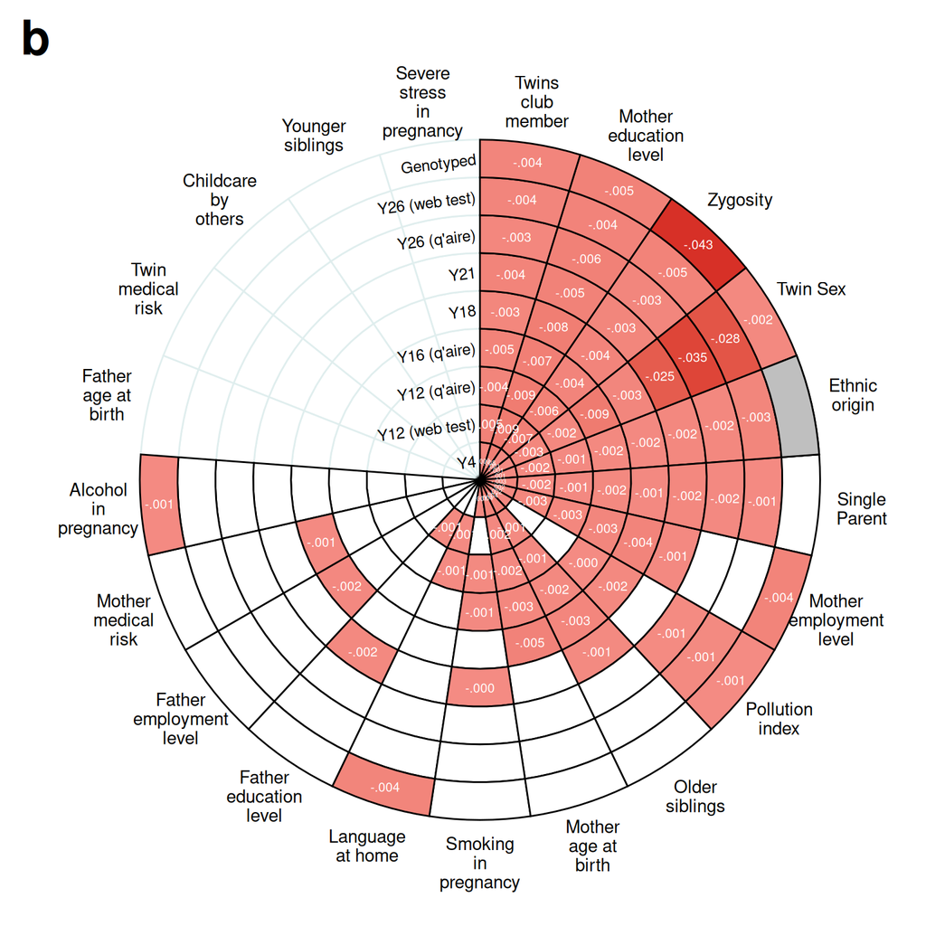

```r
rq1y_twin_labels_clean_extrashort2 = paste0(rq1y_twin_labels_clean_extrashort, " ")

# Alternative circular heatmap approach
heatmap_data = glm_model_comparison_results_df %>%
  filter(Variables_Dropped != "None") %>%
  mutate(
    outcome_labeled = rq1y_twin_labels_clean_extrashort2[match(outcome, rq1y_twin1)],
    outcome_labeled = factor(outcome_labeled, levels = rq1y_twin_labels_clean_extrashort2),
    Variables_wrapped = str_wrap(Variables_full, width = 8),
    # Set Delta_AUC to NA if not significant, otherwise keep original negative value
    # Set to grey for specific variables
    Delta_AUC_fill = case_when(
      Wald_p < 0.05 ~ abs(Delta_AUC),
      TRUE ~ NA
    )
  ) %>%
  # Join with importance ranking from above
  left_join(variable_importance, by = "Variables_full") %>%
  mutate(
    # Set factor levels based on importance ranking
    Variables_wrapped = factor(Variables_wrapped,
                              levels = unique(Variables_wrapped[order(importance_rank)]))
  )

# Add empty variables to create gap
n_vars = length(levels(heatmap_data$Variables_wrapped))
all_vars = c(levels(heatmap_data$Variables_wrapped))

heatmap_data$Variables_wrapped = factor(heatmap_data$Variables_wrapped, levels = all_vars)

# Placeholder tile for ethnicity × hasgeno1 (excluded from model by design)
ethnicity_hasgeno_row = heatmap_data %>%
  filter(Variables_Dropped == "aethnicc") %>%
  slice(1) %>%
  mutate(
    outcome         = "hasgeno1",
    outcome_labeled = rq1y_twin_labels_clean_extrashort2[match("hasgeno1", rq1y_twin1)],
    nobs = NA, AIC = NA, BIC = NA, AUC = NA, mcfad_r2 = NA, Delta_BIC = NA,Delta_AIC=NA,
    Delta_AUC       = 0,
    Delta_AUC_fill  = NA,
    Wald_p          = 1
  )

# Predictors that are never significant (Holm-adjusted p >= .05 for every
# outcome) get faded tile borders. Derived from the data rather than hardcoded.
never_significant_vars = variable_importance %>%
  filter(n_significant_05 == 0) %>%
  pull(Variables_full) %>%
  as.character()

heatmap_data = bind_rows(heatmap_data, ethnicity_hasgeno_row) %>%
  mutate(
    outcome_labeled   = factor(outcome_labeled, levels = levels(heatmap_data$outcome_labeled)),
    Variables_wrapped = factor(Variables_wrapped, levels = levels(heatmap_data$Variables_wrapped)),
    border_colour     = ifelse(as.character(Variables_full) %in% never_significant_vars, "azure2", "black")
  ) %>%
  # Draw faded tiles first so that black borders of neighbouring tiles are drawn
  # on top of any shared edge (otherwise draw order decides which colour shows)
  arrange(border_colour != "azure2")

ggplot(heatmap_data, aes(x = Variables_wrapped, y = outcome_labeled)) +
  geom_tile(aes(fill = Delta_AUC_fill, color = border_colour),
            linewidth = .5) +
  # Grey placeholder for ethnicity x genotyped (ethnicity was not in that model)
  geom_tile(data = ethnicity_hasgeno_row, fill = "grey75", color = "black", size = .5) +
  scale_color_identity() +
  geom_text(
    aes(label = ifelse(Wald_p < 0.05,
                       gsub("^(-?)0\\.", "\\1.", sprintf("%.3f", Delta_AUC)), ""),
        size = ifelse(outcome_labeled %in% c("Y4 "), 1.4, 2.8)
    ),
    color = "white"
  ) +
  scale_size_identity() +
  # Add custom y-axis labels in the gap
  coord_polar(theta = "x", start = 0, direction = 1) +
  # scale_x_discrete(drop = FALSE, labels = function(x) ifelse(grepl("GAP_", x), "", x)) +  # Hide GAP labels
  scale_fill_gradient(
    na.value = "white",
    low = "#f48c84",
    high = "#d73027",
    limits = c(0, max(heatmap_data$Delta_AUC_fill, na.rm = TRUE)),
    guide = "none"
  ) +
  # No in-figure title/subtitle (Behavior Genetics guidelines): the meaning of
  # the values (change in AUC when the variable is removed; red = significant)
  # is given in the manuscript figure caption instead. Panel letter is lowercase
  # as required by the journal.
  labs(
    tag = "b"
  ) +
  theme_minimal() +
  theme(
    axis.text.x = element_text(angle = 0, size = 11, colour = "black"),
    axis.text.y = element_blank(),  # Hide default y-axis labels
    axis.title = element_blank(),
    panel.grid = element_blank(),
    plot.tag = element_text(hjust = 0, vjust = 0, size = 30, face = "bold"),
    plot.tag.position = "topleft"
  ) +
  {
    y_positions = seq_along(levels(heatmap_data$outcome_labeled))
    labels = levels(heatmap_data$outcome_labeled)

    lapply(seq_along(labels), function(i) {
      annotate("text", x = 0.5, y = y_positions[i],
               label = labels[i], size = 3.4, hjust = 1, angle = 7)
    })
  }
```

```r
save_plot("1_rq1_heatmap_twinparticipationpredictors", width = 8, height = 8, trim = TRUE)
```

View full-size plot

### AUC and Variance Explained Plots

```r
model_metrics = do.call("rbind.data.frame", glm_model_comparison_results) %>%
  filter(Variables_full=="None") %>%
  select(-contains("Delta"),-contains("Wald")) %>%
  mutate(
    outcome = rq1y_twin_labels_clean_extrashort[match(.$outcome, rq1y_twin1)],
    outcome = factor(outcome, levels = rq1y_twin_labels_clean_extrashort)
  )

model_metrics
```

|  | Variables_Dropped | Variables_full | outcome | nobs | AIC | BIC | AUC | mcfad_r2 |
| --- | --- | --- | --- | --- | --- | --- | --- | --- |
| 1 | None | None | Y4 | 26040 | 33413.17 | 33911.38 | 0.6492102 | 0.05021463 |
| 110 | None | None | Y12 (web test) | 26040 | 33819.25 | 34317.46 | 0.6596724 | 0.05725776 |
| 113 | None | None | Y12 (q'aire) | 26040 | 33994.91 | 34493.12 | 0.6525687 | 0.05187751 |
| 115 | None | None | Y16 (q'aire) | 26040 | 32554.67 | 33052.88 | 0.6689076 | 0.06279473 |
| 117 | None | None | Y18 | 26040 | 33449.56 | 33947.77 | 0.6814120 | 0.07449996 |
| 119 | None | None | Y21 | 26040 | 32163.37 | 32661.58 | 0.6751468 | 0.06958783 |
| 120 | None | None | Y26 (q'aire) | 26040 | 31072.04 | 31570.25 | 0.6627877 | 0.05840561 |
| 128 | None | None | Y26 (web test) | 26040 | 21263.08 | 21761.29 | 0.6706336 | 0.05618055 |
| 130 | None | None | Genotyped | 26040 | 34217.22 | 34682.77 | 0.6515310 | 0.05245552 |

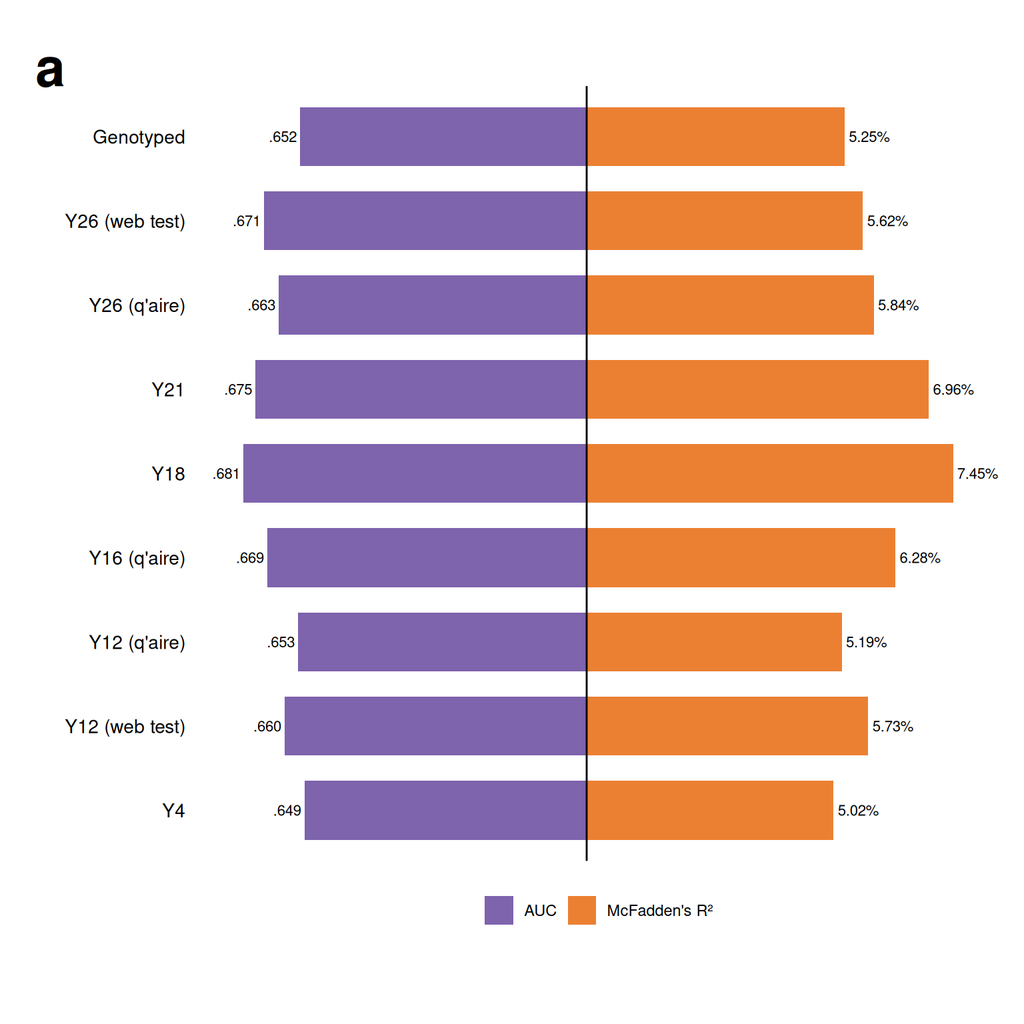

```r
plot_data = model_metrics %>%
  select(outcome, AUC, mcfad_r2) %>%
  mutate(
    AUC_scaled = -(AUC - 0.5),
    R2_scaled = mcfad_r2 * 2.6
  ) %>%
  pivot_longer(cols = c(AUC_scaled, R2_scaled), names_to = "metric", values_to = "value_scaled") %>%
  mutate(
    metric_label = case_when(
      metric == "AUC_scaled" ~ "AUC",
      metric == "R2_scaled" ~ "McFadden's R²"
    ),
    original_value = ifelse(metric == "AUC_scaled", AUC, mcfad_r2),
    label_value    = case_when(
      metric == "AUC_scaled" ~ gbtoolbox::apa_num(original_value,3),
      metric == "R2_scaled" ~ paste0(gbtoolbox::apa_num(original_value*100,2),"%")
    )
  )

ggplot(plot_data, aes(y = outcome, x = value_scaled, fill = metric_label)) +
  geom_col(width = 0.7, alpha = 0.8) +
  geom_text(aes(label = label_value),
            hjust = ifelse(plot_data$metric == "AUC_scaled", 1.1, -0.1),
            size = 2.9) +
  scale_fill_manual(values = c("AUC" = "#5e3c99", "McFadden's R²" = "#e66101")) +
  # No in-figure title (Behavior Genetics guidelines); described in the
  # manuscript caption instead. Panel letter is lowercase as required.
  labs(
    tag = "a",
    x = NULL,
    y = NULL,
    fill = NULL
  ) +
  theme_minimal() +
  coord_cartesian(clip = "off") +
  theme(
    legend.position = "bottom",
    axis.text.y = element_text(size = 10.5, angle = 0, margin = margin(r = 10, unit = "pt"), color = "black"),
    # panel.grid.major.x = element_line(color = "grey90"),
    panel.grid = element_blank(),
    plot.margin = margin(t = 20, r = 20, b = 50, l = 20, unit = "pt"),
    axis.text.x = element_blank(),
    plot.tag = element_text(hjust = 0, vjust = 0, size = 30, face = "bold"),
    plot.tag.position = "topleft"
  ) +
  geom_vline(xintercept = 0, color = "black", size = 0.5)
```

```r
save_plot("1_rq1_twinlevel_prediction_accuracy", width = 5, height = 8, trim = TRUE)
```

View full-size plot

### Twin-Level Logistic Regression Coefficients

```r
# Extract all coefficients from twin models and combine
twinmodels_results0 = do.call(rbind, lapply(1:length(twinmodels), function(i) {
    vcov_robust = clubSandwich::vcovCR(twinmodels[[i]],
                                    cluster = twinmodels[[i]]$data$famid,
                                    type = "CR2")
    coefs       = clubSandwich::conf_int(twinmodels[[i]], vcov = vcov_robust, test = "naive-tp")

    coefs$outcome = rq1y_twin1[i]
  return(coefs)
}))
twinmodels_results = twinmodels_results0 %>%
  data.frame() %>%
  dplyr::rename(term = "Coef") %>%
  `rownames<-`(NULL)


# # Extract all coefficients from twin models and combine
# twinmodels_results = do.call(rbind, lapply(1:length(twinmodels), function(i) {
#   coefs = broom::tidy(twinmodels[[i]], conf.int = FALSE) %>%
#     select(-std.error, -statistic, -p.value)
#   coefs$outcome = rq1y_twin1[i]
#   return(coefs)
# }))

twinmodels_results$var = str_extract(twinmodels_results$term, paste0("^(", paste(rq1x, collapse = "|"), ")"))
twinmodels_results$var[twinmodels_results0$Coef == "(Intercept)"] = "Intercept"
twinmodels_results$var_outcome = paste(twinmodels_results$var,twinmodels_results$outcome, sep = "_")
# Bonferonni-holm corrected p-value
twinmodels_results$Wald_p = glm_model_comparison_results_df$Wald_p[match(twinmodels_results$var_outcome,glm_model_comparison_results_df$var_outcome)]

twinmodels_results %>%
    mutate(
      outcome = rq1y_twin_labels_clean_extrashort[match(.$outcome, rq1y_twin1)],
      term = case_when(
        term == "(Intercept)" ~ "Intercept",
        term == "sex1" ~ "Twin Sex (Male)",
        term == "amumagetw" ~ "Mother age at birth",
        term == "adadagetw" ~ "Father age at birth",
        term == "aadultscohabiting biological parent with other" ~ "Household Type: Cohabiting parent",
        term == "asinglesingle parent" ~ "Single Parent (ref: cohabiting parents)",
        term == "zygos2" ~ "Zygosity (DZ)",
        term == "amedtot" ~ "Mother medical risk",
        str_starts(term, "afasoc2") & str_detect(term, "^afasoc2\\d$") ~ paste0("Father employment: Level ", str_sub(term, -1)),
        term == "afasoc2caring for children at home" ~ "Father employment: Caring for children",
        term == "afasoc2no job" ~ "Father employment: No job",
        term == "afahqualno qualifications" ~ "Father education: No qualifications",
        term == "afahqualCSE grade 2-5 or O-level/GCSE grade D-G" ~ "Father education: CSE/GCSE D-G",
        term == "afahqualA-level or S-level" ~ "Father education: A-level",
        term == "afahqualHNC" ~ "Father education: HNC",
        term == "afahqualHND" ~ "Father education: HND",
        term == "afahqualundergraduate degree" ~ "Father education: Undergraduate",
        term == "afahqualpostgraduate qualification" ~ "Father education: Postgraduate",
        str_starts(term, "amosoc2") & str_detect(term, "^amosoc2\\d$") ~ paste0("Mother employment: Level ", str_sub(term, -1)),
        term == "amosoc2no job" ~ "Mother employment: No job",
        term == "amohqualCSE grade 2-5 or O-level/GCSE grade D-G" ~ "Mother education: CSE/GCSE D-G",
        term == "amohqualCSE grade 1 or O-level/GCSE grade A-C" ~ "Mother education: CSE/GCSE A-C",
        term == "amohqualA-level or S-level" ~ "Mother education: A-level",
        term == "amohqualHNC" ~ "Mother education: HNC",
        term == "amohqualHND" ~ "Mother education: HND",
        term == "amohqualundergraduate degree" ~ "Mother education: Undergraduate",
        term == "amohqualpostgraduate qualification" ~ "Mother education: Postgraduate",
        term == "atwmed1" ~ "Twin medical risk",
        term == "aethniccAsian" ~ "Ethnic origin: Asian",
        term == "aethniccBlack" ~ "Ethnic origin: Black",
        term == "aethniccMixed race" ~ "Ethnic origin: Mixed race",
        term == "aethniccOther" ~ "Ethnic origin: Other",
        term == "alangEnglish" ~ "Language: English only",
        term == "alangEnglish + other" ~ "Language: English + other",
        str_starts(term, "anoldsib") & str_detect(term, "\\d+$") ~ paste0("Older siblings: ", str_extract(term, "\\d+")),
        term == "anoldsib5 or more" ~ "Older siblings: 5+",
        term == "anyngsib1" ~ "Younger siblings: 1",
        term == "anyngsib2 or more" ~ "Younger siblings: 2+",
        term == "atwclub1" ~ "Twins club member",
        term == "alookels1" ~ "Childcare by others",
        term == "asmoke1" ~ "Smoking in pregnancy",
        term == "adrink1" ~ "Alcohol in pregnancy",
        term == "astress1" ~ "Severe stress in pregnancy",
        term == "cens01pop98density" ~ "Population density",
        term == "pollution1998pca" ~ "Pollution index",
        TRUE ~ term
      )
    ) %>%
  mutate(
    beta = gbtoolbox::apa_num(beta, n_decimal_places = 3),
    CI_L = gbtoolbox::apa_num(CI_L, n_decimal_places = 3),
    CI_U = gbtoolbox::apa_num(CI_U, n_decimal_places = 3),
    SE   = gbtoolbox::apa_num(SE,   n_decimal_places = 3),
    Wald_p_clean = gbtoolbox::apa_num(Wald_p, n_decimal_places = 3),

    table_val = paste0(beta,"\n[",CI_L,",\n",CI_U,"]\np=",Wald_p_clean,"\nSE=", SE = SE)
  ) %>%
  select(term, table_val, Wald_p, outcome) %>%
  pivot_wider(
    id_cols = term,
    values_from = c("table_val", "Wald_p"),
    names_from = outcome
  ) %>%
  gt() %>%
  tab_style(
    style = cell_text(whitespace = "pre-wrap"),
    locations = cells_body(columns = starts_with("table_val"))
  ) %>%
  # tab_style(
  #   style = cell_fill(color = "#d5e8d4"),
  #   locations = cells_body(columns = "table_val_Y2", rows = Wald_p_Y2 < 0.05)
  # ) %>%
  # tab_style(
  #   style = cell_fill(color = "#d5e8d4"),
  #   locations = cells_body(columns = "table_val_Y3", rows = Wald_p_Y3 < 0.05)
  # ) %>%
  tab_style(
    style = cell_fill(color = "#d5e8d4"),
    locations = cells_body(columns = "table_val_Y4", rows = Wald_p_Y4 < 0.05)
  ) %>%
  # tab_style(
  #   style = cell_fill(color = "#d5e8d4"),
  #   locations = cells_body(columns = "table_val_Y7", rows = Wald_p_Y7 < 0.05)
  # ) %>%
  # tab_style(
  #   style = cell_fill(color = "#d5e8d4"),
  #   locations = cells_body(columns = "table_val_Y9", rows = Wald_p_Y9 < 0.05)
  # ) %>%
  # tab_style(
  #   style = cell_fill(color = "#d5e8d4"),
  #   locations = cells_body(columns = "table_val_Y10", rows = Wald_p_Y10 < 0.05)
  # ) %>%
  tab_style(
    style = cell_fill(color = "#d5e8d4"),
    locations = cells_body(columns = "table_val_Y12 (web test)", rows = `Wald_p_Y12 (web test)` < 0.05)
  ) %>%
  tab_style(
    style = cell_fill(color = "#d5e8d4"),
    locations = cells_body(columns = "table_val_Y12 (q'aire)", rows = `Wald_p_Y12 (q'aire)` < 0.05)
  ) %>%
  # tab_style(
  #   style = cell_fill(color = "#d5e8d4"),
  #   locations = cells_body(columns = "table_val_Y16 (web)", rows = `Wald_p_Y16 (web)` < 0.05)
  # ) %>%
  tab_style(
    style = cell_fill(color = "#d5e8d4"),
    locations = cells_body(columns = "table_val_Y16 (q'aire)", rows = `Wald_p_Y16 (q'aire)` < 0.05)
  ) %>%
  tab_style(
    style = cell_fill(color = "#d5e8d4"),
    locations = cells_body(columns = "table_val_Y18", rows = Wald_p_Y18 < 0.05)
  ) %>%
  tab_style(
    style = cell_fill(color = "#d5e8d4"),
    locations = cells_body(columns = "table_val_Y21", rows = Wald_p_Y21 < 0.05)
  ) %>%
  tab_style(
    style = cell_fill(color = "#d5e8d4"),
    locations = cells_body(columns = "table_val_Y26 (q'aire)", rows = `Wald_p_Y26 (q'aire)` < 0.05)
  ) %>%
  tab_style(
    style = cell_fill(color = "#d5e8d4"),
    locations = cells_body(columns = "table_val_Y26 (web test)", rows = `Wald_p_Y26 (web test)` < 0.05)
  ) %>%
  tab_style(
    style = cell_fill(color = "#d5e8d4"),
    locations = cells_body(columns = "table_val_Genotyped", rows = Wald_p_Genotyped < 0.05)
  ) %>%
  cols_hide(columns = starts_with("Wald_p")) %>%
  cols_label_with(
    fn = function(x) str_remove(x, "table_val_")
  ) %>%
  tab_options(
      table.width = "100%",
      table.font.size = "12px"
    ) %>%
      cols_width(
      term ~ px(90),
      starts_with("table_val") ~ px(40)
    ) %>%
  tab_source_note(
    source_note = "Note: Confidence intervals calculated using cluster robust standard errors clustered by family, calculated using the clubSandwich R package with CR2 (bias-reduced linearization) adjustment and naive-tp small sample adjustment. Cluster robust Wald tests were used to calculate using the ClubSandwich R package. Note that for dummy variables, Wald tests were performed by constraining all dummy variables in a given set to zero - therefore dummy variables derived from the same categorical variable have the same p-values."
  )
```

| term | Y4 | Y12 (web test) | Y12 (q'aire) | Y16 (q'aire) | Y18 | Y21 | Y26 (q'aire) | Y26 (web test) | Genotyped |
| --- | --- | --- | --- | --- | --- | --- | --- | --- | --- |
| Intercept | -1.156 [-1.604, -.709] p= SE= .228 | -1.645 [-2.089, -1.202] p= SE= .226 | -1.661 [-2.112, -1.211] p= SE= .230 | -1.678 [-2.142, -1.215] p= SE= .237 | -1.498 [-1.951, -1.046] p= SE= .231 | -1.349 [-1.781, -.917] p= SE= .220 | -1.187 [-1.601, -.772] p= SE= .211 | -2.183 [-2.722, -1.644] p= SE= .275 | -.637 [-1.033, -.240] p= SE= .202 |
| Twin Sex (Male) | -.109 [-.182, -.036] p= .038 SE= .037 | -.231 [-.302, -.159] p= .000 SE= .036 | -.181 [-.253, -.109] p= .000 SE= .037 | -.393 [-.467, -.319] p= .000 SE= .038 | -.253 [-.325, -.181] p= .000 SE= .037 | -.683 [-.752, -.613] p= .000 SE= .035 | -.738 [-.806, -.671] p= .000 SE= .034 | -.687 [-.774, -.599] p= .000 SE= .045 | -.153 [-.221, -.085] p= .000 SE= .035 |
| Mother age at birth | .034 [ .024, .044] p= .000 SE= .005 | .026 [ .016, .036] p= .000 SE= .005 | .026 [ .016, .036] p= .000 SE= .005 | .030 [ .019, .040] p= .000 SE= .005 | .045 [ .035, .056] p= .000 SE= .005 | .014 [ .004, .024] p= .054 SE= .005 | .012 [ .003, .022] p= .140 SE= .005 | .012 [-.001, .024] p= .543 SE= .006 | .013 [ .003, .023] p= .095 SE= .005 |
| Father age at birth | .009 [ .001, .017] p= .212 SE= .004 | .006 [-.002, .013] p= .760 SE= .004 | .007 [-.001, .015] p= .574 SE= .004 | .001 [-.008, .009] p=1.000 SE= .004 | .007 [-.001, .015] p= .571 SE= .004 | .009 [ .001, .016] p= .239 SE= .004 | .006 [-.001, .013] p=1.000 SE= .004 | .006 [-.003, .016] p=1.000 SE= .005 | -.001 [-.008, .007] p=1.000 SE= .004 |
| Single Parent (ref: cohabiting parents) | -.430 [-.593, -.268] p= .000 SE= .083 | -.397 [-.565, -.229] p= .000 SE= .086 | -.340 [-.509, -.171] p= .001 SE= .086 | -.473 [-.656, -.291] p= .000 SE= .093 | -.426 [-.591, -.261] p= .000 SE= .084 | -.546 [-.714, -.377] p= .000 SE= .086 | -.424 [-.588, -.261] p= .000 SE= .083 | -.397 [-.624, -.170] p= .010 SE= .116 | -.203 [-.357, -.049] p= .106 SE= .079 |
| Zygosity (DZ) | -.156 [-.235, -.078] p= .001 SE= .040 | -.344 [-.420, -.267] p= .000 SE= .039 | -.324 [-.402, -.247] p= .000 SE= .040 | -.287 [-.366, -.207] p= .000 SE= .041 | -.312 [-.391, -.234] p= .000 SE= .040 | -.287 [-.362, -.213] p= .000 SE= .038 | -.268 [-.340, -.196] p= .000 SE= .037 | -.327 [-.418, -.235] p= .000 SE= .047 | -.850 [-.927, -.773] p= .000 SE= .039 |
| Mother medical risk | -.029 [-.074, .016] p= .965 SE= .023 | -.045 [-.089, -.000] p= .343 SE= .023 | -.020 [-.065, .025] p= .951 SE= .023 | -.057 [-.104, -.011] p= .159 SE= .024 | -.085 [-.129, -.040] p= .002 SE= .023 | -.021 [-.064, .022] p=1.000 SE= .022 | -.031 [-.072, .011] p=1.000 SE= .021 | -.033 [-.087, .020] p=1.000 SE= .027 | -.022 [-.064, .021] p=1.000 SE= .022 |
| Father employment: Level 2 | .161 [ .021, .302] p= .525 SE= .072 | .079 [-.052, .210] p= .343 SE= .067 | .064 [-.068, .197] p= .951 SE= .068 | .125 [-.009, .259] p=1.000 SE= .068 | .160 [ .022, .297] p= .007 SE= .070 | .147 [ .020, .273] p= .141 SE= .065 | .115 [-.006, .235] p= .150 SE= .061 | .140 [-.007, .287] p=1.000 SE= .075 | .084 [-.044, .212] p=1.000 SE= .065 |
| Father employment: Level 3 | -.059 [-.209, .092] p= .525 SE= .077 | .189 [ .044, .334] p= .343 SE= .074 | .103 [-.044, .249] p= .951 SE= .075 | .059 [-.090, .208] p=1.000 SE= .076 | .066 [-.083, .216] p= .007 SE= .076 | .097 [-.043, .238] p= .141 SE= .072 | .043 [-.093, .180] p= .150 SE= .070 | .095 [-.070, .261] p=1.000 SE= .084 | -.071 [-.211, .070] p=1.000 SE= .072 |
| Father employment: Level 4 | .014 [-.190, .217] p= .525 SE= .104 | .167 [-.031, .365] p= .343 SE= .101 | .131 [-.070, .332] p= .951 SE= .103 | .097 [-.110, .303] p=1.000 SE= .105 | .003 [-.199, .206] p= .007 SE= .103 | .051 [-.143, .245] p= .141 SE= .099 | .067 [-.122, .256] p= .150 SE= .096 | .106 [-.132, .345] p=1.000 SE= .122 | -.023 [-.219, .173] p=1.000 SE= .100 |
| Father employment: Level 5 | -.052 [-.170, .066] p= .525 SE= .060 | -.024 [-.140, .092] p= .343 SE= .059 | -.029 [-.146, .087] p= .951 SE= .059 | -.101 [-.221, .020] p=1.000 SE= .061 | -.088 [-.205, .028] p= .007 SE= .059 | -.099 [-.211, .014] p= .141 SE= .057 | -.100 [-.209, .009] p= .150 SE= .056 | -.071 [-.215, .072] p=1.000 SE= .073 | -.023 [-.134, .088] p=1.000 SE= .057 |
| Father employment: Level 6 | -.110 [-.284, .064] p= .525 SE= .089 | .060 [-.109, .228] p= .343 SE= .086 | .042 [-.128, .212] p= .951 SE= .087 | .111 [-.064, .286] p=1.000 SE= .089 | .053 [-.119, .224] p= .007 SE= .087 | -.013 [-.177, .151] p= .141 SE= .084 | .008 [-.151, .167] p= .150 SE= .081 | .042 [-.161, .246] p=1.000 SE= .104 | -.031 [-.195, .133] p=1.000 SE= .084 |
| Father employment: Level 7 | -.182 [-.405, .041] p= .525 SE= .114 | .168 [-.049, .385] p= .343 SE= .111 | .101 [-.122, .324] p= .951 SE= .114 | -.014 [-.246, .217] p=1.000 SE= .118 | .082 [-.138, .301] p= .007 SE= .112 | -.032 [-.250, .185] p= .141 SE= .111 | -.011 [-.213, .192] p= .150 SE= .103 | .047 [-.213, .307] p=1.000 SE= .133 | .050 [-.163, .263] p=1.000 SE= .109 |
| Father employment: Level 8 | .032 [-.115, .178] p= .525 SE= .075 | -.019 [-.165, .126] p= .343 SE= .074 | -.101 [-.249, .046] p= .951 SE= .075 | .003 [-.148, .155] p=1.000 SE= .077 | -.052 [-.197, .094] p= .007 SE= .074 | -.072 [-.213, .069] p= .141 SE= .072 | -.046 [-.182, .089] p= .150 SE= .069 | -.140 [-.329, .049] p=1.000 SE= .096 | -.025 [-.164, .113] p=1.000 SE= .071 |
| Father employment: Level 9 | .083 [-.110, .276] p= .525 SE= .098 | .077 [-.115, .270] p= .343 SE= .098 | .100 [-.094, .294] p= .951 SE= .099 | .027 [-.175, .230] p=1.000 SE= .103 | .116 [-.074, .305] p= .007 SE= .097 | -.085 [-.275, .104] p= .141 SE= .097 | -.132 [-.316, .052] p= .150 SE= .094 | -.094 [-.345, .157] p=1.000 SE= .128 | .088 [-.094, .269] p=1.000 SE= .093 |
| Father employment: Caring for children | -.038 [-.305, .229] p= .525 SE= .136 | -.031 [-.295, .232] p= .343 SE= .134 | .020 [-.248, .287] p= .951 SE= .136 | -.049 [-.328, .230] p=1.000 SE= .142 | -.184 [-.447, .079] p= .007 SE= .134 | -.069 [-.333, .195] p= .141 SE= .135 | -.133 [-.392, .127] p= .150 SE= .132 | .000 [-.330, .331] p=1.000 SE= .169 | -.172 [-.429, .084] p=1.000 SE= .131 |
| Father employment: No job | -.112 [-.285, .062] p= .525 SE= .089 | -.136 [-.313, .041] p= .343 SE= .090 | -.120 [-.299, .059] p= .951 SE= .091 | -.123 [-.310, .064] p=1.000 SE= .095 | -.312 [-.489, -.136] p= .007 SE= .090 | -.257 [-.431, -.082] p= .141 SE= .089 | -.281 [-.453, -.109] p= .150 SE= .088 | -.153 [-.381, .075] p=1.000 SE= .116 | .011 [-.154, .177] p=1.000 SE= .084 |
| Father education: No qualifications | -.172 [-.301, -.043] p= .108 SE= .066 | -.214 [-.345, -.083] p= .030 SE= .067 | -.139 [-.272, -.006] p= .202 SE= .068 | -.174 [-.313, -.035] p= .236 SE= .071 | -.188 [-.318, -.059] p= .182 SE= .066 | -.180 [-.308, -.052] p= .012 SE= .065 | -.173 [-.299, -.048] p=1.000 SE= .064 | -.186 [-.359, -.013] p= .128 SE= .088 | -.142 [-.265, -.018] p=1.000 SE= .063 |
| Father education: CSE/GCSE D-G | -.104 [-.221, .012] p= .108 SE= .059 | -.157 [-.274, -.041] p= .030 SE= .059 | -.067 [-.185, .051] p= .202 SE= .060 | -.106 [-.228, .016] p= .236 SE= .062 | -.093 [-.209, .023] p= .182 SE= .059 | -.140 [-.255, -.026] p= .012 SE= .058 | -.083 [-.193, .028] p=1.000 SE= .056 | -.078 [-.227, .071] p= .128 SE= .076 | -.080 [-.192, .032] p=1.000 SE= .057 |
| Father education: A-level | -.158 [-.285, -.030] p= .108 SE= .065 | -.180 [-.304, -.055] p= .030 SE= .064 | -.117 [-.244, .009] p= .202 SE= .064 | -.041 [-.171, .089] p= .236 SE= .067 | -.083 [-.209, .043] p= .182 SE= .064 | -.057 [-.180, .065] p= .012 SE= .062 | -.005 [-.123, .114] p=1.000 SE= .060 | .004 [-.150, .159] p= .128 SE= .079 | -.135 [-.255, -.015] p=1.000 SE= .061 |
| Father education: HNC | .066 [-.100, .233] p= .108 SE= .085 | -.018 [-.178, .142] p= .030 SE= .081 | .085 [-.077, .246] p= .202 SE= .082 | .085 [-.080, .249] p= .236 SE= .084 | .096 [-.067, .258] p= .182 SE= .083 | .019 [-.134, .173] p= .012 SE= .078 | .013 [-.137, .162] p=1.000 SE= .076 | .014 [-.179, .207] p= .128 SE= .098 | -.063 [-.216, .090] p=1.000 SE= .078 |
| Father education: HND | -.109 [-.286, .068] p= .108 SE= .090 | .009 [-.159, .177] p= .030 SE= .086 | -.073 [-.244, .098] p= .202 SE= .087 | .014 [-.159, .186] p= .236 SE= .088 | -.070 [-.241, .102] p= .182 SE= .088 | -.006 [-.169, .157] p= .012 SE= .083 | .008 [-.151, .167] p=1.000 SE= .081 | .035 [-.165, .235] p= .128 SE= .102 | -.133 [-.296, .030] p=1.000 SE= .083 |
| Father education: Undergraduate | .034 [-.116, .185] p= .108 SE= .077 | .040 [-.102, .182] p= .030 SE= .073 | .122 [-.022, .265] p= .202 SE= .073 | .124 [-.022, .270] p= .236 SE= .074 | .045 [-.102, .192] p= .182 SE= .075 | .155 [ .018, .292] p= .012 SE= .070 | .023 [-.109, .156] p=1.000 SE= .067 | .210 [ .047, .374] p= .128 SE= .083 | -.052 [-.190, .087] p=1.000 SE= .071 |
| Father education: Postgraduate | -.149 [-.329, .031] p= .108 SE= .092 | -.022 [-.192, .148] p= .030 SE= .087 | .049 [-.124, .223] p= .202 SE= .088 | .115 [-.060, .290] p= .236 SE= .089 | -.107 [-.284, .070] p= .182 SE= .090 | .169 [ .006, .332] p= .012 SE= .083 | .061 [-.095, .217] p=1.000 SE= .080 | .256 [ .063, .450] p= .128 SE= .099 | -.135 [-.299, .030] p=1.000 SE= .084 |
| Mother employment: Level 1 | -.330 [-.493, -.166] p= .020 SE= .084 | -.019 [-.174, .136] p= .000 SE= .079 | .007 [-.151, .166] p= .001 SE= .081 | -.055 [-.215, .104] p= .000 SE= .081 | .125 [-.036, .285] p= .000 SE= .082 | .013 [-.137, .163] p= .008 SE= .077 | .008 [-.136, .151] p= .150 SE= .073 | -.023 [-.204, .157] p=1.000 SE= .092 | -.047 [-.198, .104] p= .000 SE= .077 |
| Mother employment: Level 2 | -.104 [-.294, .086] p= .020 SE= .097 | .174 [ .001, .348] p= .000 SE= .088 | .072 [-.103, .247] p= .001 SE= .089 | .057 [-.117, .232] p= .000 SE= .089 | .190 [ .004, .377] p= .000 SE= .095 | .082 [-.084, .247] p= .008 SE= .085 | -.014 [-.170, .141] p= .150 SE= .079 | -.082 [-.271, .107] p=1.000 SE= .096 | .014 [-.155, .183] p= .000 SE= .086 |
| Mother employment: Level 3 | -.043 [-.205, .118] p= .020 SE= .082 | .333 [ .182, .483] p= .000 SE= .077 | .296 [ .142, .450] p= .001 SE= .078 | .308 [ .156, .461] p= .000 SE= .078 | .459 [ .299, .620] p= .000 SE= .082 | .240 [ .098, .382] p= .008 SE= .072 | .220 [ .085, .355] p= .150 SE= .069 | .069 [-.099, .237] p=1.000 SE= .086 | .305 [ .156, .453] p= .000 SE= .076 |
| Mother employment: Level 4 | -.091 [-.218, .037] p= .020 SE= .065 | .028 [-.095, .152] p= .000 SE= .063 | -.050 [-.175, .075] p= .001 SE= .064 | -.041 [-.170, .087] p= .000 SE= .066 | .065 [-.061, .190] p= .000 SE= .064 | -.046 [-.168, .076] p= .008 SE= .062 | -.009 [-.127, .110] p= .150 SE= .061 | -.103 [-.257, .052] p=1.000 SE= .079 | -.069 [-.189, .052] p= .000 SE= .062 |
| Mother employment: Level 5 | -.148 [-.563, .268] p= .020 SE= .212 | .162 [-.230, .553] p= .000 SE= .200 | -.056 [-.451, .338] p= .001 SE= .201 | .010 [-.417, .437] p= .000 SE= .218 | .055 [-.358, .469] p= .000 SE= .211 | .040 [-.337, .417] p= .008 SE= .192 | .231 [-.113, .575] p= .150 SE= .176 | .052 [-.407, .511] p=1.000 SE= .234 | .256 [-.147, .659] p= .000 SE= .205 |
| Mother employment: Level 6 | -.168 [-.329, -.008] p= .020 SE= .082 | .124 [-.034, .282] p= .000 SE= .081 | .069 [-.091, .229] p= .001 SE= .082 | .046 [-.118, .209] p= .000 SE= .083 | -.055 [-.214, .104] p= .000 SE= .081 | -.077 [-.231, .076] p= .008 SE= .078 | -.006 [-.156, .144] p= .150 SE= .077 | -.176 [-.376, .025] p=1.000 SE= .102 | .025 [-.128, .179] p= .000 SE= .078 |
| Mother employment: Level 7 | -.194 [-.373, -.016] p= .020 SE= .091 | .011 [-.166, .187] p= .000 SE= .090 | -.076 [-.255, .103] p= .001 SE= .091 | -.241 [-.430, -.052] p= .000 SE= .096 | -.204 [-.382, -.027] p= .000 SE= .091 | -.204 [-.381, -.027] p= .008 SE= .090 | -.120 [-.291, .051] p= .150 SE= .087 | -.105 [-.333, .124] p=1.000 SE= .117 | -.241 [-.411, -.070] p= .000 SE= .087 |
| Mother employment: Level 8 | -.123 [-.486, .239] p= .020 SE= .185 | -.118 [-.489, .254] p= .000 SE= .190 | -.277 [-.659, .106] p= .001 SE= .195 | -.379 [-.798, .040] p= .000 SE= .214 | -.420 [-.784, -.055] p= .000 SE= .186 | -.327 [-.713, .060] p= .008 SE= .197 | -.072 [-.431, .288] p= .150 SE= .183 | -.186 [-.678, .306] p=1.000 SE= .251 | -.240 [-.586, .105] p= .000 SE= .176 |
| Mother employment: Level 9 | -.016 [-.270, .238] p= .020 SE= .130 | .200 [-.053, .453] p= .000 SE= .129 | .138 [-.120, .396] p= .001 SE= .132 | -.085 [-.357, .186] p= .000 SE= .139 | .032 [-.225, .289] p= .000 SE= .131 | .071 [-.178, .321] p= .008 SE= .127 | .089 [-.146, .324] p= .150 SE= .120 | .022 [-.293, .337] p=1.000 SE= .161 | -.041 [-.284, .202] p= .000 SE= .124 |
| Mother employment: No job | -.202 [-.314, -.089] p= .020 SE= .057 | -.159 [-.274, -.045] p= .000 SE= .058 | -.209 [-.324, -.093] p= .001 SE= .059 | -.268 [-.390, -.146] p= .000 SE= .062 | -.184 [-.297, -.070] p= .000 SE= .058 | -.154 [-.266, -.041] p= .008 SE= .057 | -.122 [-.232, -.012] p= .150 SE= .056 | -.152 [-.300, -.004] p=1.000 SE= .075 | -.272 [-.379, -.165] p= .000 SE= .055 |
| Mother education: CSE/GCSE D-G | .300 [ .146, .454] p= .000 SE= .079 | .202 [ .036, .367] p= .000 SE= .084 | .194 [ .028, .360] p= .000 SE= .085 | .188 [ .010, .365] p= .000 SE= .091 | .280 [ .121, .440] p= .000 SE= .082 | .241 [ .077, .405] p= .000 SE= .084 | .144 [-.016, .304] p= .000 SE= .082 | .039 [-.188, .265] p= .000 SE= .116 | .181 [ .032, .331] p= .000 SE= .076 |
| Mother education: CSE/GCSE A-C | .433 [ .291, .576] p= .000 SE= .073 | .475 [ .323, .626] p= .000 SE= .077 | .412 [ .259, .564] p= .000 SE= .078 | .408 [ .246, .570] p= .000 SE= .083 | .527 [ .380, .675] p= .000 SE= .075 | .456 [ .306, .606] p= .000 SE= .077 | .337 [ .190, .484] p= .000 SE= .075 | .293 [ .087, .499] p= .000 SE= .105 | .311 [ .173, .448] p= .000 SE= .070 |
| Mother education: A-level | .475 [ .308, .642] p= .000 SE= .085 | .622 [ .449, .795] p= .000 SE= .088 | .583 [ .409, .757] p= .000 SE= .089 | .589 [ .407, .771] p= .000 SE= .093 | .669 [ .498, .839] p= .000 SE= .087 | .559 [ .389, .729] p= .000 SE= .087 | .507 [ .342, .672] p= .000 SE= .084 | .499 [ .275, .723] p= .000 SE= .114 | .404 [ .244, .564] p= .000 SE= .082 |
| Mother education: HNC | .715 [ .455, .976] p= .000 SE= .133 | .717 [ .462, .972] p= .000 SE= .130 | .602 [ .345, .859] p= .000 SE= .131 | .554 [ .291, .817] p= .000 SE= .134 | .718 [ .463, .972] p= .000 SE= .130 | .622 [ .380, .864] p= .000 SE= .124 | .518 [ .280, .756] p= .000 SE= .121 | .415 [ .100, .730] p= .000 SE= .161 | .603 [ .357, .848] p= .000 SE= .125 |
| Mother education: HND | .542 [ .310, .774] p= .000 SE= .119 | .738 [ .509, .968] p= .000 SE= .117 | .709 [ .476, .943] p= .000 SE= .119 | .464 [ .223, .705] p= .000 SE= .123 | .740 [ .508, .971] p= .000 SE= .118 | .442 [ .217, .667] p= .000 SE= .115 | .321 [ .106, .535] p= .000 SE= .110 | .298 [ .010, .587] p= .000 SE= .147 | .477 [ .256, .698] p= .000 SE= .113 |
| Mother education: Undergraduate | .764 [ .572, .957] p= .000 SE= .098 | .808 [ .618, .999] p= .000 SE= .097 | .763 [ .570, .956] p= .000 SE= .098 | .732 [ .532, .931] p= .000 SE= .102 | .885 [ .692, 1.078] p= .000 SE= .098 | .730 [ .544, .916] p= .000 SE= .095 | .693 [ .513, .872] p= .000 SE= .092 | .510 [ .270, .749] p= .000 SE= .122 | .622 [ .442, .801] p= .000 SE= .092 |
| Mother education: Postgraduate | .952 [ .713, 1.190] p= .000 SE= .122 | .696 [ .469, .923] p= .000 SE= .116 | .617 [ .387, .846] p= .000 SE= .117 | .590 [ .354, .825] p= .000 SE= .120 | .815 [ .584, 1.047] p= .000 SE= .118 | .724 [ .504, .945] p= .000 SE= .113 | .685 [ .474, .896] p= .000 SE= .108 | .560 [ .287, .833] p= .000 SE= .139 | .586 [ .370, .801] p= .000 SE= .110 |
| Twin medical risk | .000 [-.041, .042] p=1.000 SE= .021 | -.029 [-.069, .011] p= .760 SE= .021 | -.040 [-.081, .001] p= .437 SE= .021 | -.020 [-.061, .022] p=1.000 SE= .021 | -.013 [-.053, .028] p=1.000 SE= .021 | -.010 [-.049, .029] p=1.000 SE= .020 | .002 [-.035, .040] p=1.000 SE= .019 | .052 [ .004, .099] p= .356 SE= .024 | -.047 [-.086, -.009] p= .164 SE= .020 |
| Ethnic origin: Asian | .081 [-.229, .391] p= .019 SE= .158 | .127 [-.189, .443] p= .006 SE= .161 | .162 [-.159, .482] p= .042 SE= .164 | .216 [-.106, .538] p= .009 SE= .164 | .314 [-.005, .634] p= .004 SE= .163 | .385 [ .088, .681] p= .000 SE= .151 | .059 [-.226, .345] p= .000 SE= .146 | .407 [ .077, .736] p= .001 SE= .168 | NA |
| Ethnic origin: Black | -.559 [-.857, -.261] p= .019 SE= .152 | -.452 [-.766, -.139] p= .006 SE= .160 | -.503 [-.820, -.187] p= .042 SE= .162 | -.605 [-.949, -.261] p= .009 SE= .175 | -.328 [-.629, -.027] p= .004 SE= .153 | -.576 [-.894, -.257] p= .000 SE= .163 | -.532 [-.824, -.239] p= .000 SE= .149 | -.908 [-1.422, -.394] p= .001 SE= .262 | NA |
| Ethnic origin: Mixed race | -.142 [-.357, .072] p= .019 SE= .109 | -.382 [-.603, -.160] p= .006 SE= .113 | -.236 [-.459, -.014] p= .042 SE= .114 | -.275 [-.508, -.041] p= .009 SE= .119 | -.336 [-.558, -.113] p= .004 SE= .114 | -.394 [-.614, -.174] p= .000 SE= .112 | -.398 [-.612, -.185] p= .000 SE= .109 | -.306 [-.583, -.029] p= .001 SE= .141 | NA |
| Ethnic origin: Other | -.339 [-.784, .106] p= .019 SE= .227 | -.125 [-.594, .344] p= .006 SE= .239 | .119 [-.337, .575] p= .042 SE= .233 | .079 [-.408, .566] p= .009 SE= .248 | -.404 [-.894, .086] p= .004 SE= .250 | -.107 [-.567, .353] p= .000 SE= .235 | .142 [-.321, .605] p= .000 SE= .236 | .206 [-.344, .757] p= .001 SE= .281 | NA |
| Language: English only | .286 [-.017, .588] p= .211 SE= .154 | .317 [ .017, .617] p= .023 SE= .153 | .337 [ .029, .646] p= .036 SE= .157 | .306 [-.007, .620] p= .672 SE= .160 | -.089 [-.400, .222] p=1.000 SE= .159 | .283 [-.004, .571] p= .311 SE= .147 | .136 [-.141, .413] p=1.000 SE= .141 | .173 [-.183, .530] p=1.000 SE= .182 | .747 [ .488, 1.007] p= .000 SE= .132 |
| Language: English + other | -.089 [-.459, .280] p= .211 SE= .188 | -.217 [-.600, .165] p= .023 SE= .195 | -.171 [-.563, .221] p= .036 SE= .200 | .056 [-.351, .462] p= .672 SE= .207 | -.106 [-.483, .271] p=1.000 SE= .192 | -.015 [-.377, .348] p= .311 SE= .185 | -.150 [-.503, .203] p=1.000 SE= .180 | -.167 [-.630, .297] p=1.000 SE= .237 | .057 [-.301, .416] p= .000 SE= .183 |
| Older siblings: 1 | -.201 [-.286, -.115] p= .000 SE= .044 | -.017 [-.100, .065] p= .004 SE= .042 | -.054 [-.137, .030] p= .007 SE= .043 | -.073 [-.158, .013] p= .015 SE= .044 | -.133 [-.217, -.049] p= .000 SE= .043 | -.094 [-.174, -.013] p= .008 SE= .041 | -.111 [-.188, -.033] p= .087 SE= .040 | -.115 [-.215, -.016] p= .169 SE= .051 | .017 [-.063, .097] p= .546 SE= .041 |
| Older siblings: 2 | -.280 [-.398, -.161] p= .000 SE= .060 | -.095 [-.211, .021] p= .004 SE= .059 | -.166 [-.284, -.049] p= .007 SE= .060 | -.175 [-.297, -.053] p= .015 SE= .062 | -.296 [-.414, -.179] p= .000 SE= .060 | -.178 [-.291, -.064] p= .008 SE= .058 | -.192 [-.303, -.081] p= .087 SE= .057 | -.102 [-.244, .040] p= .169 SE= .072 | .099 [-.013, .210] p= .546 SE= .057 |
| Older siblings: 3 | -.554 [-.737, -.371] p= .000 SE= .093 | -.217 [-.408, -.025] p= .004 SE= .098 | -.258 [-.451, -.065] p= .007 SE= .098 | -.302 [-.508, -.097] p= .015 SE= .105 | -.414 [-.606, -.223] p= .000 SE= .098 | -.277 [-.466, -.087] p= .008 SE= .096 | -.164 [-.345, .018] p= .087 SE= .093 | -.331 [-.586, -.075] p= .169 SE= .130 | .003 [-.174, .181] p= .546 SE= .091 |
| Older siblings: 4 | -.504 [-.856, -.153] p= .000 SE= .179 | -.664 [-1.059, -.269] p= .004 SE= .201 | -.507 [-.882, -.132] p= .007 SE= .191 | -.578 [-.988, -.167] p= .015 SE= .210 | -.514 [-.882, -.147] p= .000 SE= .188 | -.546 [-.921, -.172] p= .008 SE= .191 | -.030 [-.386, .325] p= .087 SE= .182 | -.251 [-.734, .232] p= .169 SE= .246 | -.355 [-.696, -.015] p= .546 SE= .174 |
| Older siblings: 5+ | -1.022 [-1.607, -.438] p= .000 SE= .298 | -1.052 [-1.773, -.332] p= .004 SE= .368 | -.849 [-1.524, -.174] p= .007 SE= .344 | -.396 [-1.067, .275] p= .015 SE= .342 | -.989 [-1.644, -.334] p= .000 SE= .334 | -.355 [-.940, .229] p= .008 SE= .298 | -.356 [-.966, .255] p= .087 SE= .311 | -1.195 [-2.284, -.105] p= .169 SE= .556 | -.439 [-1.018, .140] p= .546 SE= .295 |
| Younger siblings: 1 | -.185 [-.398, .027] p= .965 SE= .108 | -.210 [-.422, .003] p= .760 SE= .108 | -.254 [-.473, -.036] p= .517 SE= .111 | -.126 [-.347, .094] p=1.000 SE= .112 | -.135 [-.348, .079] p=1.000 SE= .109 | -.131 [-.341, .079] p= .925 SE= .107 | -.141 [-.346, .064] p=1.000 SE= .105 | -.034 [-.288, .219] p=1.000 SE= .129 | .020 [-.179, .219] p=1.000 SE= .102 |
| Younger siblings: 2+ | -.230 [-.941, .480] p= .965 SE= .363 | -.060 [-.732, .613] p= .760 SE= .343 | -.037 [-.754, .680] p= .517 SE= .366 | -.229 [-.948, .490] p=1.000 SE= .367 | -.079 [-.700, .542] p=1.000 SE= .317 | -.450 [-1.087, .186] p= .925 SE= .325 | -.576 [-1.331, .178] p=1.000 SE= .385 | -1.076 [-2.304, .152] p=1.000 SE= .626 | .248 [-.370, .866] p=1.000 SE= .315 |
| Twins club member | .223 [ .140, .306] p= .000 SE= .042 | .309 [ .231, .387] p= .000 SE= .040 | .267 [ .188, .346] p= .000 SE= .040 | .324 [ .244, .405] p= .000 SE= .041 | .257 [ .177, .338] p= .000 SE= .041 | .321 [ .245, .396] p= .000 SE= .039 | .251 [ .178, .324] p= .000 SE= .037 | .278 [ .186, .369] p= .000 SE= .047 | .267 [ .190, .344] p= .000 SE= .039 |
| Childcare by others | -.121 [-.230, -.012] p= .212 SE= .056 | -.044 [-.150, .062] p= .836 SE= .054 | -.065 [-.172, .043] p= .951 SE= .055 | -.066 [-.176, .044] p=1.000 SE= .056 | .131 [ .022, .239] p= .170 SE= .056 | .003 [-.099, .106] p=1.000 SE= .052 | .039 [-.060, .138] p=1.000 SE= .050 | .027 [-.098, .153] p=1.000 SE= .064 | -.045 [-.148, .057] p=1.000 SE= .052 |
| Smoking in pregnancy | -.207 [-.308, -.105] p= .001 SE= .052 | -.145 [-.248, -.042] p= .059 SE= .053 | -.227 [-.332, -.122] p= .000 SE= .053 | -.262 [-.372, -.152] p= .000 SE= .056 | -.104 [-.206, -.001] p= .327 SE= .052 | -.151 [-.252, -.050] p= .042 SE= .052 | -.081 [-.179, .017] p=1.000 SE= .050 | -.168 [-.299, -.038] p= .148 SE= .067 | -.055 [-.152, .042] p=1.000 SE= .049 |
| Alcohol in pregnancy | -.012 [-.098, .074] p=1.000 SE= .044 | .088 [ .005, .171] p= .293 SE= .042 | .056 [-.028, .140] p= .951 SE= .043 | .002 [-.083, .088] p=1.000 SE= .044 | .040 [-.044, .125] p=1.000 SE= .043 | -.059 [-.140, .022] p= .907 SE= .041 | -.050 [-.128, .028] p=1.000 SE= .040 | -.104 [-.203, -.005] p= .391 SE= .050 | .141 [ .061, .222] p= .007 SE= .041 |
| Severe stress in pregnancy | -.013 [-.109, .082] p=1.000 SE= .049 | -.023 [-.117, .071] p= .836 SE= .048 | .008 [-.087, .103] p= .951 SE= .049 | .024 [-.074, .122] p=1.000 SE= .050 | -.001 [-.095, .094] p=1.000 SE= .048 | .005 [-.087, .097] p=1.000 SE= .047 | .005 [-.084, .094] p=1.000 SE= .045 | -.036 [-.150, .078] p=1.000 SE= .058 | -.073 [-.163, .016] p= .872 SE= .046 |
| Pollution index | -.096 [-.135, -.058] p= .000 SE= .020 | -.050 [-.087, -.013] p= .080 SE= .019 | -.051 [-.089, -.013] p= .083 SE= .019 | -.057 [-.095, -.018] p= .047 SE= .020 | -.098 [-.136, -.060] p= .000 SE= .019 | -.041 [-.078, -.005] p= .239 SE= .019 | -.063 [-.098, -.028] p= .007 SE= .018 | -.079 [-.124, -.034] p= .010 SE= .023 | -.068 [-.103, -.033] p= .002 SE= .018 |

Note: Confidence intervals calculated using cluster robust standard errors clustered by family, calculated using the clubSandwich R package with CR2 (bias-reduced linearization) adjustment and naive-tp small sample adjustment. Cluster robust Wald tests were used to calculate using the ClubSandwich R package. Note that for dummy variables, Wald tests were performed by constraining all dummy variables in a given set to zero - therefore dummy variables derived from the same categorical variable have the same p-values.

## RQ1: Marginal Effects of Maternal Education on Participation

The plot below shows, for each study wave, the model-predicted probability of participation at each level of maternal education (with 95% CIs), holding all other predictors at their observed means/modes. This illustrates how strongly and consistently maternal education predicts later participation across timepoints.

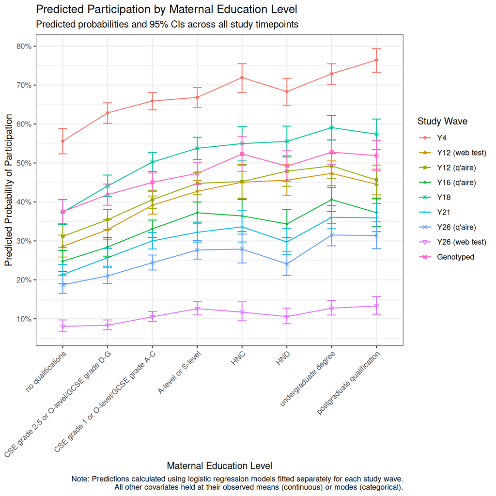

```r
# Calculate average predictions for maternal education variables

# Calculate predictions for all models

all_predictions = map_dfr(1:length(twinmodels), function(i) {
  data_grid = marginaleffects::datagrid(
    model = twinmodels[[i]],
    amohqual = unique
  )

  pred = predict(twinmodels[[i]], newdata = data_grid, type = "link", se.fit = TRUE)
  cbind.data.frame(
    data_grid,
    estimate = plogis(pred$fit),
    conf.low  = plogis(pred$fit - 1.96 * pred$se.fit),
    conf.high = plogis(pred$fit + 1.96 * pred$se.fit)
  ) %>%
    mutate(
      outcome = rq1y_twin_labels_clean_extrashort[i],
      amohqual = factor(amohqual, levels = levels(df$amohqual))
    )
})

# Plot all predictions together
all_predictions %>%
  mutate(
    outcome = factor(outcome, levels = rq1y_twin_labels_clean_extrashort)
  ) %>%
  ggplot(aes(x = amohqual, y = estimate, group = outcome, color = outcome, shape = outcome)) +
  geom_point() +
  geom_line() +
  geom_errorbar(aes(ymin = conf.low, ymax = conf.high), width = 0.2) +
  scale_shape_manual(values = c(16, 17, 15, 18, 8, 3, 4, 25, 7)) +
  scale_y_continuous(
    breaks = seq(0, 1, by = 0.1),
    labels = scales::percent_format(accuracy = 1)
  ) +
  theme_bw() +
  theme(axis.text.x = element_text(angle = 45, hjust = 1)) +
  labs(
    title = "Predicted Participation by Maternal Education Level",
    subtitle = "Predicted probabilities and 95% CIs across all study timepoints",
    x = "Maternal Education Level",
    y = "Predicted Probability of Participation",
    color = "Study Wave",
    shape = "Study Wave",
    caption = "Note: Predictions calculated using logistic regression models fitted separately for each study wave.\nAll other covariates held at their observed means (continuous) or modes (categorical)."
  )
```

## RQ1: Marginal Effects of Ethnicity on Participation

The plot below shows, for each study wave, the model-predicted probability of participation at each level of ethnic origin (with 95% CIs), holding all other predictors at their observed means/modes. This illustrates how strongly and consistently ethnicity predicts later participation across timepoints.

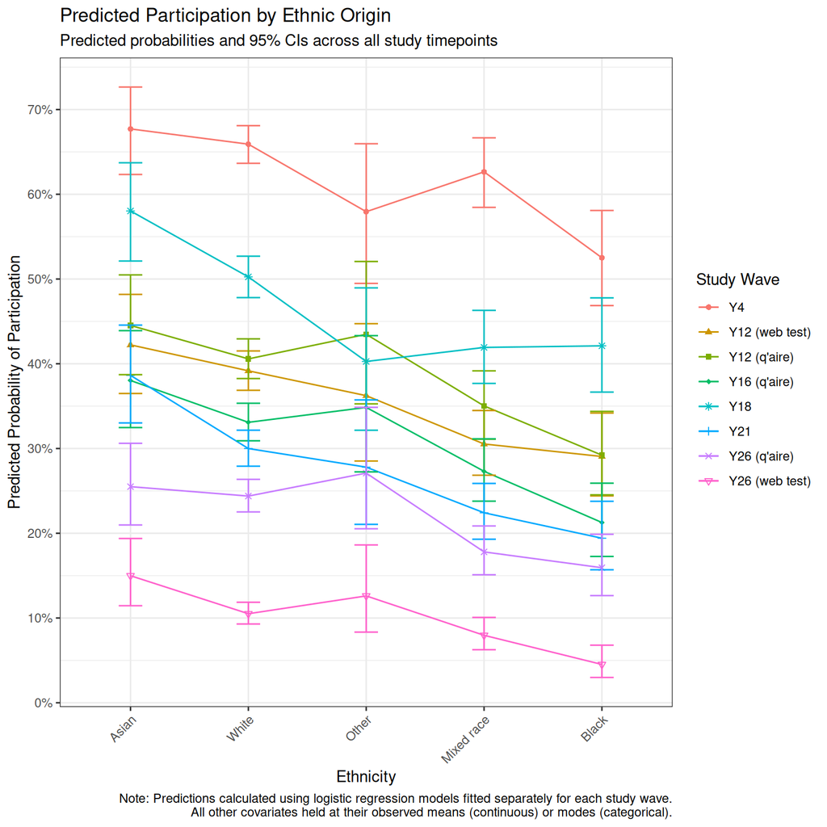

```r
# Calculate average predictions for ethnicity

# Calculate predictions for all models

all_predictions_ethnicity = map_dfr(1:(length(twinmodels)-1), function(i) {
  data_grid = marginaleffects::datagrid(
    model = twinmodels[[i]],
    aethnicc = unique
  )

  pred = predict(twinmodels[[i]], newdata = data_grid, type = "link", se.fit = TRUE)
  cbind.data.frame(
    data_grid,
    estimate = plogis(pred$fit),
    conf.low  = plogis(pred$fit - 1.96 * pred$se.fit),
    conf.high = plogis(pred$fit + 1.96 * pred$se.fit)
  ) %>%
    mutate(
      outcome = rq1y_twin_labels_clean_extrashort[i],
      aethnicc = factor(aethnicc, levels = levels(df$aethnicc))
    )
})

# Plot all predictions together
all_predictions_ethnicity %>%
  mutate(
    outcome = factor(outcome, levels = rq1y_twin_labels_clean_extrashort),
    aethnicc = factor(
      aethnicc,
      levels = c("Asian", "White", "Other", "Mixed race", "Black")
    )
  ) %>%
  ggplot(aes(x = aethnicc, y = estimate, group = outcome, color = outcome, shape = outcome)) +
  geom_point() +
  geom_line() +
  geom_errorbar(aes(ymin = conf.low, ymax = conf.high), width = 0.2) +
  scale_shape_manual(values = c(16, 17, 15, 18, 8, 3, 4, 25, 7)) +
  scale_y_continuous(
    breaks = seq(0, 1, by = 0.1),
    labels = scales::percent_format(accuracy = 1)
  ) +
  theme_bw() +
  theme(axis.text.x = element_text(angle = 45, hjust = 1)) +
  labs(
    title = "Predicted Participation by Ethnic Origin",
    subtitle = "Predicted probabilities and 95% CIs across all study timepoints",
    x = "Ethnicity",
    y = "Predicted Probability of Participation",
    color = "Study Wave",
    shape = "Study Wave",
    caption = "Note: Predictions calculated using logistic regression models fitted separately for each study wave.\nAll other covariates held at their observed means (continuous) or modes (categorical)."
  )
```

# Descriptive Statistics

Total number of families with no predictor information (and are just completely removed from the analysis): 0

## Participation rates at each timepoint

```r
df %>%
  select(all_of(rq1y_twin1)) %>%
  sapply(., function(x) length(which(x==1))/length(which(x>=0)))
```

```
 dtwdata1  lcwdata1  lcqdata1 pcbhdata1  rcqdata1  u1cdata1  zmhdata1   zcdata1  hasgeno1
0.6001152 0.4415899 0.4401306 0.3807988 0.5290323 0.3747312 0.3263057 0.1547235 0.5405089
```

```r
df %>%
  select(all_of(rq1y_twin1)) %>%
  mutate(across(everything(), as.character)) %>%
  # rename_from_labels() %>%
  pivot_longer(cols = everything()) %>%
  group_by(name) %>%
  count(value) %>%
  # mutate(name_count = n()) %>%
  # filter(name_count < 10) %>%
  # select(-name_count) %>%
  knitr::kable()
```

| name | value | n |
| --- | --- | --- |
| dtwdata1 | 0 | 10413 |
| dtwdata1 | 1 | 15627 |
| hasgeno1 | 0 | 10997 |
| hasgeno1 | 1 | 12936 |
| hasgeno1 | NA | 2107 |
| lcqdata1 | 0 | 14579 |
| lcqdata1 | 1 | 11461 |
| lcwdata1 | 0 | 14541 |
| lcwdata1 | 1 | 11499 |
| pcbhdata1 | 0 | 16124 |
| pcbhdata1 | 1 | 9916 |
| rcqdata1 | 0 | 12264 |
| rcqdata1 | 1 | 13776 |
| u1cdata1 | 0 | 16282 |
| u1cdata1 | 1 | 9758 |
| zcdata1 | 0 | 22011 |
| zcdata1 | 1 | 4029 |
| zmhdata1 | 0 | 17543 |
| zmhdata1 | 1 | 8497 |

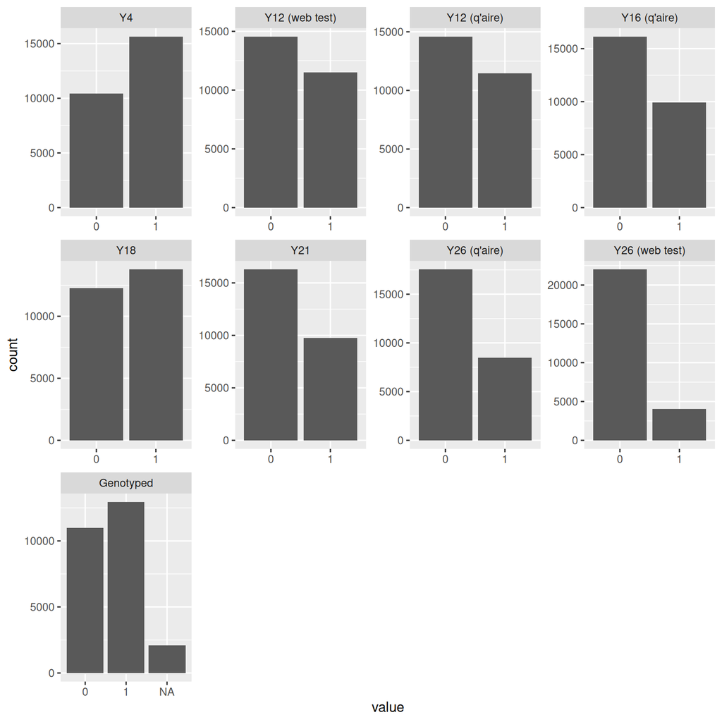

```r
df %>%
  select(all_of(rq1y_twin1)) %>%
  `colnames<-`(rq1y_twin_labels_clean_extrashort) %>%
  # select(where(is.numeric)) %>%
  mutate(across(everything(), as.character)) %>%
  mutate(across(everything(), ~as.character(replace_na(., "NA")))) %>%
  pivot_longer(cols = everything()) %>%
  mutate(name = factor(name, levels = rq1y_twin_labels_clean_extrashort)) %>%
  ggplot(aes(x=value)) +
  geom_bar() +
  facet_wrap(~name, ncol = 4, scales = "free")
```

## Predictor variables (rq1x)

### Distribution

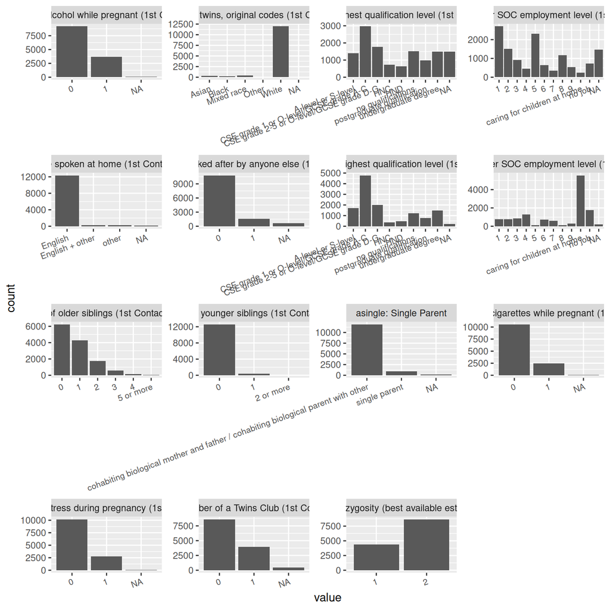

```r
df_rq1x %>%
  select(!where(is.numeric)) %>%
  rename_from_labels() %>%
  mutate(across(everything(), as.character)) %>%
  pivot_longer(cols = everything()) %>%
  ggplot(aes(x=value)) +
  geom_bar() +
  facet_wrap(~name, ncol = 4, scales = "free") +
    theme(
    axis.text.x = element_text(
      angle = 20,
      hjust = 1,
      vjust = 1,     # Middle vertical alignment
      size = 8         # Adjust text size if needed
    ))
```

### Missingness

```r
df_rq1x %>%
  mutate(across(everything(), ~ as.numeric(!is.na(.)))) %>%
  pivot_longer(
    cols = everything()
  ) %>%
  group_by(name) %>%
  summarise(percent_notmissing = mean(value)) %>%
  knitr::kable()
```

| name | percent_notmissing |
| --- | --- |
| adadagetw | 0.8824885 |
| adrink | 0.9900922 |
| aethnicc | 0.9963902 |
| afahqual | 0.8852535 |
| afasoc2 | 0.8877112 |
| alang | 0.9860983 |
| alookels | 0.9520737 |
| amedtot | 0.9932412 |
| amohqual | 0.9842550 |
| amosoc2 | 0.9850230 |
| amumagetw | 0.9816436 |
| anoldsib | 1.0000000 |
| anyngsib | 1.0000000 |
| asingle | 0.9827957 |
| asmoke | 0.9958525 |
| astress | 0.9942396 |
| atwclub | 0.9656682 |
| atwmed1 | 0.9921659 |
| pollution1998pca | 0.8841782 |
| sex1 | 1.0000000 |
| zygos | 1.0000000 |

## Missing Data Patterns

[figure not shown]

```r
df_rq1x %>%
  `colnames<-`((rq1x_labels)) %>%
  as_tibble() %>%
  ggmice::plot_pattern(., rotate = TRUE)
```

```
 /\     /\
{  `---'  }
{  O   O  }
==>  V <==  No need for mice. This data set is completely observed.
 \  \|/  /
  `-----'
```

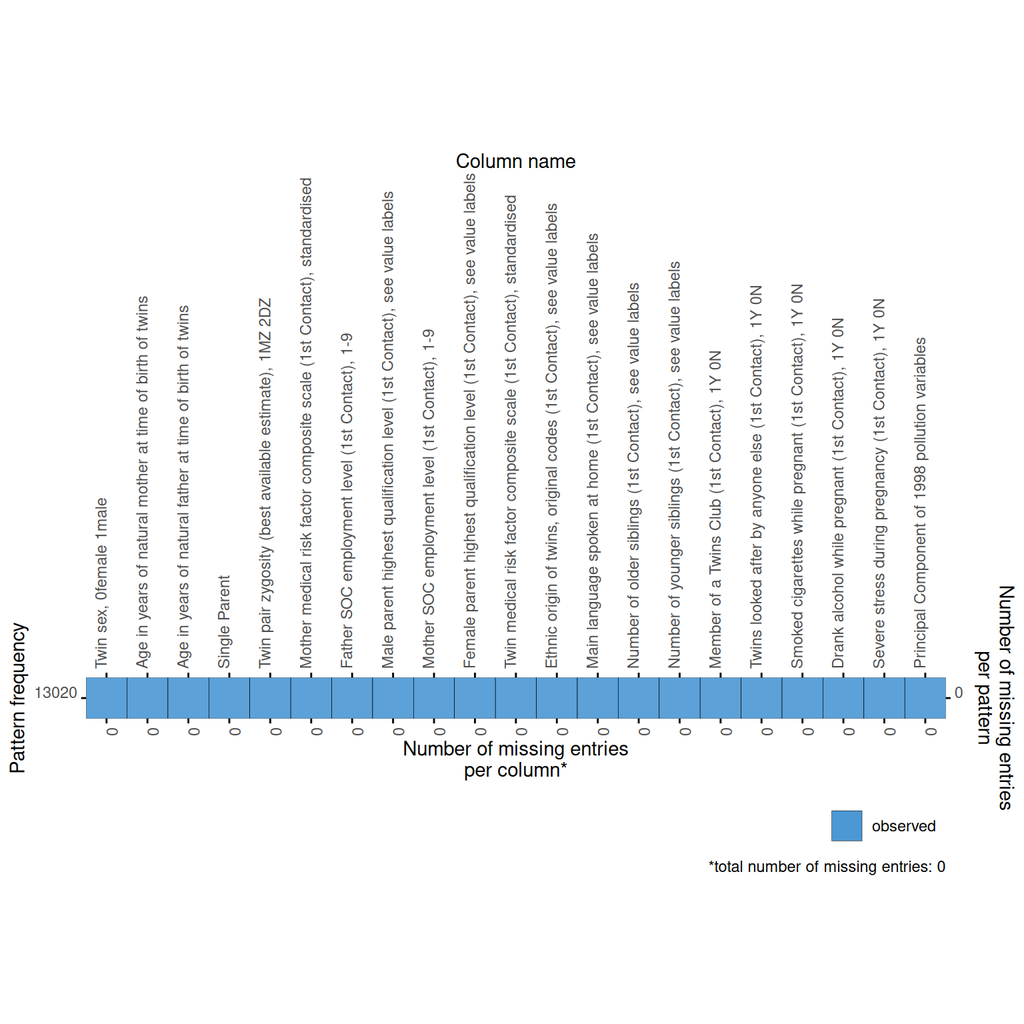

```r
save_plot("1_rq1_misssing_data_pattern", width = 12, height = 30)

df_rq1_imputed %>%
  select(rq1x) %>%
  data.frame() %>%
  `colnames<-`((rq1x_labels)) %>%
  as_tibble() %>%
  ggmice::plot_pattern(., rotate = TRUE)
```

```r
save_plot("1_rq1_misssing_data_pattern_imputed", width = 12, height = 30)
```

View full-size plot

View full-size plot

# Predicting missingness of SDQ/MFQ data

## Data Prep

1 = Not missing

[Note that at Yr16,](https://datadictionary.teds.ac.uk/studies/derived_variables/16yr_derived_variables.htm#pbhsdq) the emotion subtest was not administered to parents, so the conduct one is used instead.

```r
list_of_sdq_var = c(
  # "bsdqcemot1",
  # "csdqcemot1",
  # "dsdqemot1",
  # "gpsdqemot1",
  # "icsdqemot1", "ipsdqemot1",
  "lcsdqemot1", "lpsdqemot1",
  "pcbhsdqemot1", "ppbhsdqcont1",
  "u1csdqemot1", "ucv1sdqemot1", "u1psdqemot1",
  "zmhsdqemot1"
)

rq1m = c(
  "lcsdqemot1", "lpsdqemot1", "lcmfqt1", "lpmfqt1",
  "pcbhsdqemot1", "ppbhsdqcont1", "pcbhmfqt1", "ppbhmfqt1",
  "u1csdqemot1", "ucv1sdqemot1", "u1psdqemot1", "u1cmfqt1", "ucv1mfqt1",

  "zmhsdqemot1", "zmhmfqt1"
)

rq1m_childmeasures = c(
  "lcsdqemot1", "lcmfqt1",
  "pcbhsdqemot1", "pcbhmfqt1",
  "u1csdqemot1", "ucv1sdqemot1",  "u1cmfqt1", "ucv1mfqt1",
  "zmhsdqemot1", "zmhmfqt1"
)

rq1m_parentmeasures = c(
  "lpsdqemot1",  "lpmfqt1",
  "ppbhsdqcont1","ppbhmfqt1",
  "u1psdqemot1"
)

missing_outcomes = df %>%
  filter(acontact == 1) %>%
  select(all_of(rq1m)) %>%
  sapply(.,function(x) as.numeric(!is.na(x)))

# missing_outcomes = sapply(xx,function(x) as.numeric(is.na(x)))
```

## Descriptives

```r
data.frame(
  var = rq1m,
  labels = var_to_label(rq1m),
  p_notmissing = apply(missing_outcomes, 2, function(x) length(which(x==1))/length(x)*100) %>% round()
)
```

|  | var | labels | p_notmissing |
| --- | --- | --- | --- |
| lcsdqemot1 | lcsdqemot1 | SDQ Emotion scale (child self-report) at 12, 0-10 | 44 |
| lpsdqemot1 | lpsdqemot1 | SDQ Emotion scale (parent) at 12, 0-10 | 44 |
| lcmfqt1 | lcmfqt1 | MFQ scale from 11 MFQ items (child self-report) at 12, 0-22 | 44 |
| lpmfqt1 | lpmfqt1 | MFQ scale from 11 MFQ items (parent) at 12, 0-22 | 44 |
| pcbhsdqemot1 | pcbhsdqemot1 | SDQ Emotion scale (child behaviour qnr at 16), 0-10 | 38 |
| ppbhsdqcont1 | ppbhsdqcont1 | SDQ Conduct scale (parent behaviour qnr at 16), 0-10 | 38 |
| pcbhmfqt1 | pcbhmfqt1 | MFQ total scale (child behaviour qnr at 16), 0-26 | 38 |
| ppbhmfqt1 | ppbhmfqt1 | MFQ total scale (parent behaviour qnr at 16), 0-22 | 38 |
| u1csdqemot1 | u1csdqemot1 | SDQ Emotion total score (TEDS21 phase 1 twin qnr), 0-10 | 35 |
| ucv1sdqemot1 | ucv1sdqemot1 | SDQ Emotion total score (Covid phase 1 twin qnr), 0-10 | 18 |

[output cut: 5 more lines]

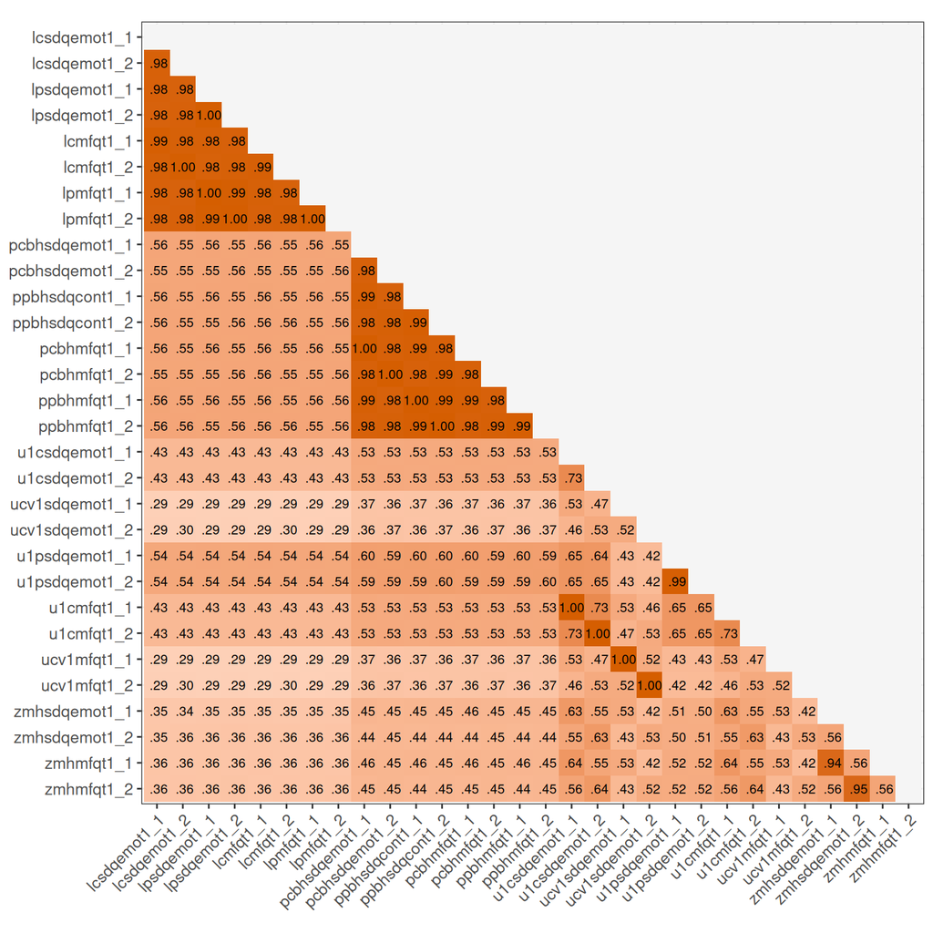

```r
# Check how concordant missingness is between twins

df %>%
  filter(acontact == 1) %>%
  select("randomfamid", "twin", all_of(rq1m)) %>%
  # rename_from_labels() %>%
  pivot_wider(id_cols = randomfamid, values_from = rq1m, names_from = twin) %>%
  mutate(
    across(
      ends_with("1") | ends_with("2"),
      ~as.numeric(!is.na(.))
    )
  ) %>%
  select(-randomfamid) %>%
  gbtoolbox::plot_correlations(
    confidence_interval = FALSE,
    sample_size = FALSE
  )
```

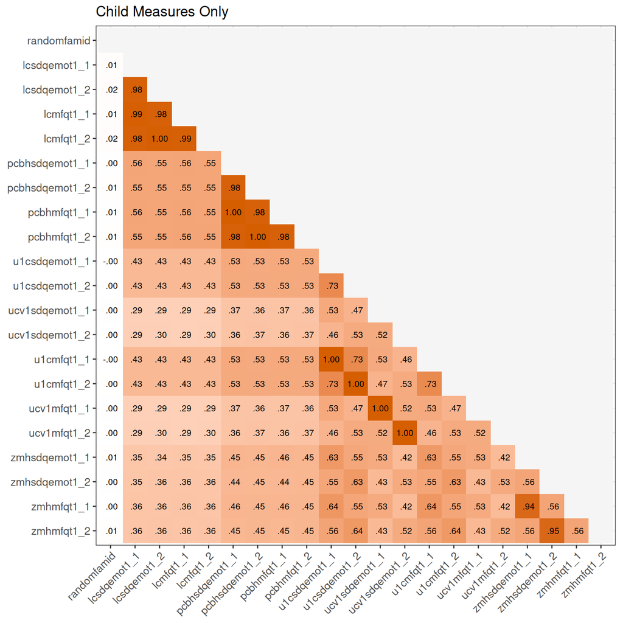

```r
df %>%
  filter(acontact == 1) %>%
  select("randomfamid", "twin", all_of(rq1m_childmeasures)) %>%
  # rename_from_labels() %>%
  pivot_wider(id_cols = randomfamid, values_from = rq1m_childmeasures, names_from = twin) %>%
  mutate(
    across(
      ends_with("1") | ends_with("2"),
      ~as.numeric(!is.na(.))
    )
  ) %>%
  gbtoolbox::plot_correlations(
    confidence_interval = FALSE,
    sample_size = FALSE
  ) +
  labs(title = "Child Measures Only")
```

```r
cbind.data.frame(df)
```